# CESifo Working Paper no. 10845

Converted from PDF `Macaluso-SkillRemotenessPostLayoff-2023-CESifo.pdf` · 73 pages · anchors: page `#pN`, block `#pN-bK`

Page 1

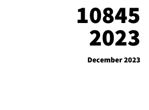

NOTE: figure/graphic rendered as an image from the PDF; its content is not machine-readable text. Caption (if any) follows as the next block.

**text found inside the figure**

**10845 2023**

**December 2023**

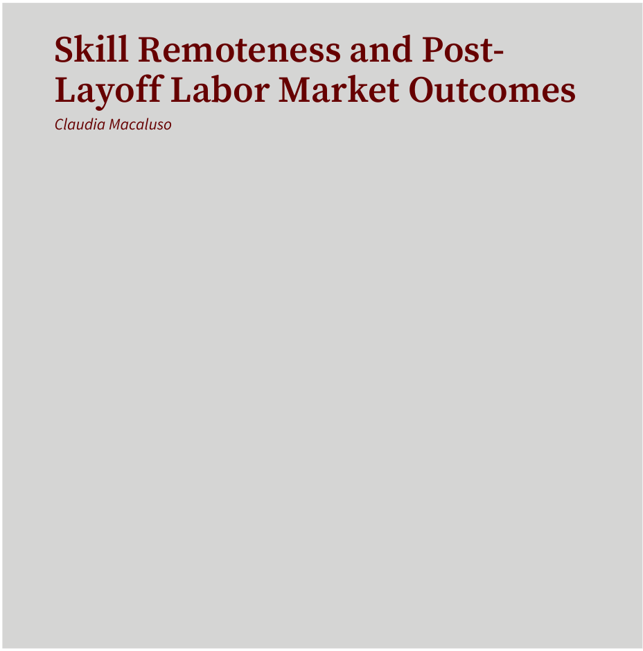

NOTE: figure/graphic rendered as an image from the PDF; its content is not machine-readable text. Caption (if any) follows as the next block.

**text found inside the figure**

**Skill Remoteness and Post- Layoff Labor Market Outcomes**

*Claudia Macaluso*

Electronic copy available at: https://ssrn.com/abstract=4676763

Page 2

### **Impressum:**

CESifo Working Papers ISSN 2364-1428 (electronic version) Publisher and distributor: Munich Society for the Promotion of Economic Research - CESifo GmbH The international platform of Ludwigs-Maximilians University’s Center for Economic Studies and the ifo Institute Poschingerstr. 5, 81679 Munich, Germany Telephone +49 (0)89 2180-2740, Telefax +49 (0)89 2180-17845, email office@cesifo.de Editor: Clemens Fuest https://www.cesifo.org/en/wp An electronic version of the paper may be downloaded · from the SSRN website: www.SSRN.com · from the RePEc website: www.RePEc.org · from the CESifo website: https://www.cesifo.org/en/wp

Electronic copy available at: https://ssrn.com/abstract=4676763

Page 3

CESifo *Working Paper No. 10845*

## Skill Remoteness and Post-Layoff Labor Market

## Outcomes

Abstract

This paper quantifies how the local skill remoteness of a laid-off worker’s last job affects subsequent wages, employment, and mobility rates. Local skill remoteness captures the degree of dissimilarity between the skill profiles of the worker’s last job and all other jobs in a local labor market. I implement a measure of local skill remoteness at the occupation-city level and find that higher skill remoteness at layoff is associated with persistently lower earnings after layoff. Earnings differences between workers whose last job was above or below median skill remoteness amount to a loss of more than $10,000 over 4 years, and are mainly accounted for by lower wages upon re-employment (not lower hours worked). Workers who lost a skill-remote job also have a higher probability of changing occupation, a lower probability of being re-employed at jobs with similar skill profiles, and a higher propensity to migrate to another city after layoff. Finally, I show that jobs destroyed in recessions are more skill-remote than those lost in booms. Taking all these facts together, I conclude that the local skill remoteness of jobs is an empirically relevant factor to understand the severity and cyclicality of displaced workers’ earnings losses and reallocation patterns.

JEL-Codes: E240, J240, J630.

Keywords: mismatch, job loss, worker reallocation, occupational change, migration.

*Claudia Macaluso FRB Richmond / VA / USA claudia.macaluso@rich.frb.org* February 18, 2023 This paper is part of my doctoral dissertation at the University of Chicago. I thank my advisors Steven J. Davis, Loukas Karabarbounis, Robert Shimer, and Jonathan Dingel for their valuable comments and encouragement. In addition, this paper benefited from conversations with many others, among whom Gadi Barlevy, Stephane Bonhomme, Katka Borovičková, Jeff Campbell, Mariacristina De Nardi, Max Dvorkin, Jason Faberman, Erik Hurst, John B. Jones, Thibaut Lamadon, Derek Neal, Aaron Pancost, Ayşegül Şahin, and Chen Yeh, in addition to audiences at the University of Chicago, University of Minnesota, Federal Reserve Banks of New York, Chicago, St. Louis, and Richmond, the Federal Reserve Board, the University of Rochester, the NBER SI 2017 Macro Perspectives group, and the 2020 CeMent Mentoring Workshop.

Electronic copy available at: https://ssrn.com/abstract=4676763

Page 4

2

### **1 Introduction**

This paper quantifies how the *local skill remoteness* of a laid-off worker’s last job

affects subsequent wages, employment, and mobility rates. Local skill remoteness

measures the degree of dissimilarity between the skill profiles of a worker’s job and all

other jobs in a local labor market. In the presence of search frictions, such disparities

may affect both individual economic outcomes and aggregate allocative efficiency.

However, whether such effects are quantitatively relevant, and along which dimen-

sions, is an open question. The literature, for instance, has shown that mismatch

between vacancies and job seekers, across industries and occupations, explains only

a modest portion of cyclical fluctuations in the aggregate unemployment rate (S¸ahin

et al., 2014; Patterson et al., 2016; Herz and van Rens, 2019). Should, then, mis-

match be written off as a minor phenomenon in the economics of labor markets?

This paper argues that it needs not be so, as I find that the effects of mismatch

extend to wages and workers’ reallocation patterns.

I propose the concept of local skill remoteness as a measure of skill mismatch between

jobs in a local labor market. I then leverage rich micro-data on workers’ careers from

the National Longitudinal Survey of Youth 1979 (NLSY79) and build on the well-

established literature on the individual effects of job displacement, to show how local

skill remoteness affects wages and reallocation rates, in addition to employment.

I provide evidence that workers who are displaced from a job more locally skill-

remote than the median (a “skill-remote” job) have persistently lower earnings than

comparable workers who lost a job less locally skill-remote than the median (a

“skill-central” job). Lower earnings are mainly accounted for by lower wages upon

re-employment (not lower hours worked). Workers laid-off from a skill-remote job

also have a lower probability to be re-employed at jobs with similar skill profiles,

a factor contributing to their lower earnings. I conclude that local skill remoteness

is an empirically relevant factor in determining the severity of post-displacement

earnings losses and the reallocation patterns that bring them about — which in

turn supports the hypothesis that mismatch affects the labor market well beyond

its documented modest influence on employment rates.

Post-displacement earnings losses are more severe when layoff happens during an

economic downturn (Jacobson et al., 1993; Davis and von Wachter, 2011). Local

skill remoteness speaks to this margin, as well. In particular, I find that jobs de-

stroyed in recessions are more likely to be locally skill-remote than those destroyed in

booms. Data from the Current Population Survey (CPS) 1996-2017 shows that the

Electronic copy available at: https://ssrn.com/abstract=4676763

Page 5

3

percentage of destroyed skill-remote jobs is 60.3% in recessions and 46.6% in booms.

Because losing a skill-remote job is associated with larger earnings losses, this fact

contributes to accounting for the cyclicality of displaced workers’ earnings losses.

It also complements existing narratives which identify in occupational change and

human capital losses the underlying reasons for large and cyclical post-displacement

earnings losses (Huckfeldt, 2021; Jarosch, 2021). To this respect, local skill remote-

ness offers a way to identify vulnerable workers even before layoff occurs — thus it

is a potentially useful tool to effectively target policy interventions.

My measure of local skill remoteness incorporates two potential sources of frictions

to worker reallocation. First, differences in the skill content of jobs which imply

imperfect substitutability between workers of different occupational backgrounds.

Second, heterogeneity in the availability of jobs across different geographical loca-

tions, a consequence of spatial specialization patterns and costly geographic mobil-

ity. To capture these two margins, I follow three steps. First, I use detailed O*NET

data on the skill content of occupations to characterize jobs as vectors of skills and

compute skill distances between them. This first step results in a matrix of pairwise

skill distances between occupations. Then, to consider how plentiful various jobs

are in different locations, I calculate occupational shares for different metropolitan

areas using data from the Occupational Employment Statistics (OES). Finally, for

each job in a given metropolitan area, I calculate the average distance between

that job and all other occupations (including itself) in the metropolitan area, using

the occupational shares as weights. This yields a measure of how similar the skills

utilized in one occupation are to those in the many other jobs in each local labor

market. This employment-weighted average distance is what I call a job’s *local skill*

*remoteness*.

The empirical local skill remoteness measure displays substantial cross-sectional vari-

ation across occupations in the same location and for the same occupation across

locations. Such variation reflects known specialization patterns across cities and

highlights how these patterns create geographically distinct “skill clusters” across

local labor markets. Consider, for example, the following two metro areas: Char-

lotte, NC and San Diego, CA. Charlotte has developed into a hub of production and

transportation jobs, with American Airlines, Lowe’s, Compass, and Carolina Bev-

erage Corporation Inc. (two food manufacturers) among the local large employers.

In San Diego, the largest employers are the University of California San Diego and

its associated hospital system, two large Healthcare providers (Sharp Health-Care

Electronic copy available at: https://ssrn.com/abstract=4676763

Page 6

4

and Scripps Health) and Qualcomm (a creator of semiconductors, software, and

services related to wireless technology). Estimated occupational skill distances —

which I incorporate in local skill remoteness — show that the skills required in av-

erage retail and transportation jobs are more similar to those utilized in the average

production job, than those in a typical healthcare or engineering position. Hence,

Production occupations are relatively more skill-remote in San Diego than they are

in Charlotte.

I exploit cross-sectional and time variation in the local skill remoteness of jobs to

study how the local skill remoteness of a worker’s job *at the time of layoff* affects

the worker’s recovery *after layoff*. Detailed individual labor market histories from

the NLSY79 allow me to evaluate earnings losses associated with displacement from

a skill-remote job. In the month of layoff, the earnings of workers whose last job was

locally skill-remote are on average $491.18 lower than workers whose last job was

locally skill-central. The difference is economically and statistically significant until

4 years after job loss and stable at around $200 per month. Overall, in the course

of 4 years after layoff, workers who were laid-off from a locally skill-remote job earn

an estimated $10,111.49 *less* than workers who were laid-off from a locally skill-

central job — approximately 5 months of the median worker’s pre-layoff income.

On average, the earnings losses after layoff are 17.7% larger for skill-remote workers

over a 4-years period, a significant difference.

Most of the long-term earnings losses associated with skill remoteness at layoff are

accounted for by lower wages at re-employment, not reduced hours worked. This

fact points to the potential for mismatch between the skills used in the pre-layoff

job and the current one to significantly affect displaced workers’ wages — while not

having a substantial impact on employment rates. Skill remoteness substantially af-

fects workers’ mobility rates, as well. Skill-remote laid-off workers are more prone to

both occupational and locational change, even 4 years after displacement. Skill re-

moteness at job loss is a good predictor of the direction of such changes; skill-remote

laid-off workers are, on average, re-employed in an occupation whose skill content

is further from the previous job’s skill profile than skill-central workers. Migration

rates across cities are also directed: workers who leave their city of residence after

layoff tend to reduce their occupation’s skill remoteness in the new location. The

difference in local skill remoteness between the two locations is increasing in the

level at origin, and more so than a random migration scenario would predict.

In conclusion, evidence from the NLSY79 highlights how workers laid-off from a

Electronic copy available at: https://ssrn.com/abstract=4676763

Page 7

5

skill-remote job experience more severe earnings losses than comparable skill-central

workers, partially on account of more frequent and significant occupational changes.

Skill-remote workers are also more likely to migrate to a new city after layoff. I

interpret this evidence as suggesting that local skill remoteness, a measure of skill

mismatch between jobs, affects workers’ post-layoff outcomes through wage changes

and reallocation patterns — even as it does not influence their employment rate.

Together with the fact that jobs lost in recessions tend to be disproportionately

skill-remote than those destroyed in booms, the evidence from displaced workers

suggests that the effects of mismatch on the labor market may extend well beyond

its small contribution to employment changes.

**Contribution to the literature** This paper primarily contributes to two strands

of literature: the effects of mismatch on employment, wages, and worker reallocation,

and the role of specific human capital in the consequences of job loss.

Studies of skill mismatch have broadly fallen into two categories: “macro” and

“micro”. The goal of this paper is to bridge these two strands and address the open

questions at their intersection.

The “macro” literature employs structural approaches to compute mismatch as de-

viations from the optimal allocation in a model of choice and focuses largely on

business cycle frequency. S¸ahin et al. (2014) is a compelling example of this ap-

proach, where the authors investigate the contribution of mismatch to changes in

aggregate employment during the Great Recession. Using a similar empirical strat-

egy and data from the United Kingdom, Patterson et al. (2016) document, instead,

the effect of mismatch on labor productivity growth. Hertz and van Rens (2019)

also calibrate a structural framework to a system of sectorally and geographically

distinct markets and estimate a modest contribution of increases in mismatch to

increases in unemployment of U.S. workers since the 1990s.

The “micro” strand of the literature utilizes empirical measures of mismatch that

are predicated on models of individual behavior and speak primarily to individual

outcomes. Andersson et al. (2018); Marinescu and Rathelot (2018); Manning and

Petrongolo (2017) propose mismatch measures that arise from job openings not

being located in the same geographic location as job seekers (geographic mismatch

only).<sup>1</sup> On the other hand, Guvenen et al. (2020) use an empirical measure of

1These papers provide robust evidence that workers prefer jobs that are close to their local area

of residence. I interpret their results as a compelling argument in favor of a local definition of labor

Electronic copy available at: https://ssrn.com/abstract=4676763

Page 8

6

skill mismatch that emphasizes occupational skills but does not take into account

differences across space (occupational mismatch only), building upon the seminal

work of Gathmann and Schoenberg (2010) — the first to propose occupational skill

distances as a measure of mismatch.<sup>2</sup>

Lastly, my work contributes to the literature on earnings losses after displacement

by investigating variation in workers’ local skill remoteness at the time of layoff.

Existing studies have focused largely on understanding why workers laid-off dur-

ing recessions experience worse labor market outcomes than those laid-off during

booms (Jacobson et al., 1993; Farber et al., 1993; Davis and von Wachter, 2011;

Krolikowski, 2017; Huckfeldt, 2021; Jarosch, 2021). This paper reaffirms the view

that the loss of (specialized) human capital emerges as a significant factor in ac-

counting for post-layoff losses. Specifically, I show that jobs destroyed in recessions

are disproportionately locally skill-remote and that losing a skill-remote job is asso-

ciated with larger earnings losses after layoff.<sup>3</sup>

**Structure of the paper** The paper is organized as follows: section 2 intro-

duces my local skill remoteness measure and the data I use to implement it at

the occupation-city level. With a measure of local skill remoteness in hand for all

occupations and metropolitan areas, section 3 describes how the local skill remote-

ness of jobs varies in the cross-section and over the business cycle. Section 4 moves

on to investigate how skill remoteness at layoff affects earnings, employment, and

workers’ mobility, using individual labor market histories in the NLSY79. Section

5 discusses the interpretation of my results and their robustness by comparing the

NLSY79 analysis with similar empirical exercises in the CPS Displaced Workers

Survey (DWS) and assessing the role of selection on unobservables. Section 6 con-

cludes.

markets.

2I also build upon Gathmann and Schoenberg (2010), who use a measure of average distance

similar to skill remoteness in this paper as an instrumental variable (see footnote 20 on page 31 in

their paper), arguing that such a measure would be orthogonal to a worker’s unobserved ability.

3Neffke, Otto, and Hidalgo (2018) explore a related idea: whether the local *industry* mix

matters for how job-seekers trade off geographical against skill distance. This paper complements

their analysis by proposing a classification of (dis)similarities between jobs based on occupational

skills, not cross-industry flows, thus isolating the component of worker flows that pertains to specific

human capital differences.

Electronic copy available at: https://ssrn.com/abstract=4676763

Page 9

7

### **2 Local skill remoteness**

#### **2.1 Conceptual framework**

The starting point of my analysis is modeling jobs as vectors of skills. The distance

in the skill space between two vectors is then a natural way to assess the dissimilarity

between the two jobs. Let *a* = 1*,...,A* denote skill attributes and *j* = 1*,...,J* index

jobs. Denote by *ℓja* the level of skill *a* demanded by job *j*, which can therefore be

understood as vector of length *A*:

*jobj* = [*ℓj*1*, ..., ℓjA*]

**equation / math rendering (image)**

NOTE: contains mathematical notation; text above is the PDF text layer and symbols may be mis-extracted. Image shows the original.

so that the skill distance between two jobs, *j* and *j*<sup>′</sup>, is the following absolute norm:<sup>4</sup>

*djj*<sup>′</sup> = <sup>1</sup>

**equation / math rendering (image)**

NOTE: contains mathematical notation; text above is the PDF text layer and symbols may be mis-extracted. Image shows the original.

*A*

**equation / math rendering (image)**

NOTE: contains mathematical notation; text above is the PDF text layer and symbols may be mis-extracted. Image shows the original.

*A* ∑ *a*=1

**equation / math rendering (image)**

NOTE: contains mathematical notation; text above is the PDF text layer and symbols may be mis-extracted. Image shows the original.

∣*ℓja* −*ℓj*<sup>′</sup>*a*∣ (1)

**equation / math rendering (image)**

NOTE: contains mathematical notation; text above is the PDF text layer and symbols may be mis-extracted. Image shows the original.

Naturally, the distance between two jobs of the same type *djj* is zero (they utilize the

same skills), and the distance between *j* and *j*<sup>′</sup> is the same as the distance between *j*<sup>′</sup>

and *j*. Occupational distances as in (1) allow for pairwise comparisons between one

job and another: the larger the distance in the skill space between two jobs, the more

dissimilar are the jobs. Such pairwise distances predict occupational transitions

with great accuracy, as shown in Appendix C.2. Furthermore, literature has shown

that such distances can account for individual wage dynamics and occupational

mobility, especially of young workers (Gathmann and Sch¨onberg, 2010; Guvenen et

al., 2020).

I build on the skill distance in (1) to provide a measure of how a specific job *j*

relates to *all* the jobs in a location — not simply to another job *j*<sup>′</sup>. Therefore,

loosely speaking, I offer a way to distinguish between jobs whose skill profile is

similar to *many* jobs in a local labor market (skill-central jobs), in contrast to jobs

whose skill profile is similar to *few* jobs in a local labor market (skill-remote jobs).

To do so, I introduce the concept of local skill remoteness as follows:

R*jc* =

**equation / math rendering (image)**

NOTE: contains mathematical notation; text above is the PDF text layer and symbols may be mis-extracted. Image shows the original.

*J* ∑ *k*=1

**equation / math rendering (image)**

NOTE: contains mathematical notation; text above is the PDF text layer and symbols may be mis-extracted. Image shows the original.

*ωkcdjk* (2)

**equation / math rendering (image)**

NOTE: contains mathematical notation; text above is the PDF text layer and symbols may be mis-extracted. Image shows the original.

where *c* = 1*,...,C* denotes local labor markets (cities) and I omit the time subscript

for ease of notation. A job’s local skill-remoteness is a weighted average of pairwise

skill distances, where the weights reflect the spatial distribution of economic activity.

4Using the Euclidean distance in (1) yields very similar results.

Electronic copy available at: https://ssrn.com/abstract=4676763

Page 10

8

In my baseline implementation, local skill remoteness explicitly takes into account a

location’s peculiar job mix through the use of each job’s local employment shares as

*ωjc*. These are used to weigh the pairwise distances across jobs’ skill profiles, thus

providing a way to emphasize the skill distance between *j* and other jobs which are

plentiful in market *c* (while playing down the skill distance between *j* and jobs that

account for a smaller employment share in *c*). As a consequence of the design in

2, any job *j* will display a different level of local skill remoteness across locations,

depending on what other jobs make up the local job mix. At the same time, jobs

*j* and *j*<sup>′</sup> will have different R*jc* even when in the same location because of the

differences in each job’s skill attributes, and how these relate to the skill profiles of

other jobs in *c*.

There is another insightful way to see how local skill remoteness captures the avail-

ability of jobs which are meaningful possibilities for a worker whose last job is in

occupation *j*.<sup>5</sup> Let me rewrite (2) as

R*jc* =

**equation / math rendering (image)**

NOTE: contains mathematical notation; text above is the PDF text layer and symbols may be mis-extracted. Image shows the original.

*J* ∑ *k*=1

**equation / math rendering (image)**

NOTE: contains mathematical notation; text above is the PDF text layer and symbols may be mis-extracted. Image shows the original.

*djkωkc*

**equation / math rendering (image)**

NOTE: contains mathematical notation; text above is the PDF text layer and symbols may be mis-extracted. Image shows the original.

so that a job’s local skill remoteness is a weighted average of local employment

shares, where the weights are the pairwise skill distances from job *j* to any other

job *j*<sup>′</sup>. For a given employment share, the larger the skill distance, the higher the

weight of occupation *j*<sup>′</sup> (a job “possibility”) in *j*’s local skill remoteness. Indeed,

a large skill distance between the two occupations implies that job *j*<sup>′</sup> is, to some

extent, “meaningless” to workers in occupation *j*. As a consequence, the larger the

skill distance between *j*<sup>′</sup> and *j*, the more the local share of jobs in occupation *j*<sup>′</sup> will

contribute to make *j* skill-remote in *c*.

In what follows, let median skill remoteness be denoted by M*ct* and correspond to

jobs have higher local skill remoteness than M*ct* and 50% of jobs have lower local

skill remoteness value than M*ct*. I will use the term “locally skill-remote job” (or

simply, “skill-remote job”) for any job whose local skill remoteness is larger than

M*ct*, and “locally skill-central” (or simply, “skill-central”) for any job whose local

5I thank an anonymous referee for suggesting this interpretation.

Electronic copy available at: https://ssrn.com/abstract=4676763

Page 11

9

skill remoteness is smaller than M*ct*.<sup>6</sup>

#### **2.2 Empirical implementation**

#### **2.2.1 Occupational skills data from O*NET**

To operationalize the notion of local skill remoteness in (2), I follow the literature in

presuming that the first-order dimension of skill heterogeneity is at the occupation

level, thus I identify “jobs” with “occupations” (Kambourov and Manovskii, 2008).

I then use the Occupational information Network (O*NET) as my primary source

for occupational skills in the U.S. labor market.<sup>7</sup>

O*NET describes more than 900 detailed occupations in the United States, span-

ning the years 2000-2017. Its core information is the mix of knowledge, skills, and

abilities that occupations require. To conduct my analysis, I identify 22 aggregate

occupational groups corresponding to the 2-digit SOC classification. Examples are

Computer and Math occupations; Healthcare occupations; Sales occupations; Pro-

duction occupations; Transportation occupations. To characterize the skill portfolio

of these occupational groups, I use the *Skills* descriptor. In the O*NET question-

naire, skills are defined as “the ability to perform a task well, usually developed over

time through training or experience, that can be used to do work in many jobs or in

learning.” Workers are asked to indicate “ the level [of each skill] *needed* to perform

the [worker’s] current job” on a scale from 1 to 7. For example, the Skills descrip-

tor in O*NET explicitly considers abilities and attitudes a worker may learn and

ameliorate on the job, such as *Active Listening*, *Service orientation* and *Complex*

*problem solving*.<sup>8</sup>

Skill data from O*NET complements other sources and offers a few advantages

6The average, city-level skill remoteness of jobs is computed as follows:

¯R*c* =

*J* ∑ *j*=1

**equation / math rendering (image)**

NOTE: contains mathematical notation; text above is the PDF text layer and symbols may be mis-extracted. Image shows the original.

*ωjc*R*jc* (3)

**equation / math rendering (image)**

NOTE: contains mathematical notation; text above is the PDF text layer and symbols may be mis-extracted. Image shows the original.

7The literature also recognizes the role of industry-specific knowledge and skills. However, data

on industry-specific skill portfolios does not exist. Consequently, although local skill remoteness only

varies at the occupation-city level, all empirical specifications in this paper will include extensive

industry controls (Neal, 1995, 1999; Pavan, 2011).

8The literature has used with success also individual qualities — such as *Physical strength* or

*General intelligence* (Poletaev and Robinson, 2008) — and operations workers carry out — such

as *Setting limits and tolerances* (Autor et al., 2003). A full list of occupations and related skills, in

addition to several illustrative examples, is found in Appendix A.1.

Electronic copy available at: https://ssrn.com/abstract=4676763

Page 12

10

of their own. Skills characterize human capital developed on-the-job more closely

than other attributes, since they explicitly identify characteristics “developed [. . . ]

through training or experience”. By definition, then, skills can be taught, practiced,

and potentially used in many professions — while specific tasks or innate abilities

cannot. Therefore, focusing on skills, rather than tasks or abilities, is particularly in-

formative to provide insights towards promoting the career development of displaced

workers.<sup>9</sup> At the same time, much literature highlights how skills are not perfectly

transferable across jobs, thus generating a cost to occupational switches and a po-

tential role for the last job’s local skill remoteness in explaining the consequences of

layoff (Neal, 1995, 1999; Kambourov and Manovskii, 2009a,b; Poletaev and Robin-

son, 2008). Indeed, I find that the skill distance as measured through O*NET data

is a major determinant of cross-occupational flows (Appendix C.2).<sup>10</sup>

As an example of occupational skills familiar to most readers of this article, con-

sider the occupation of an economist. As described by O*NET, the three skills an

average economist uses the most are *Critical Thinking*: using logic and reasoning to

identify the strengths and weaknesses of alternative solutions; *Mathematics*: using

mathematics to solve problems; and *Reading Comprehension*: understanding writ-

ten sentences and paragraphs in work related documents. Among the skills that

economists do *not* use in their job, we find skills closely associated with social work,

such as *Social Perceptiveness*: being aware of others’ reactions and understand-

ing why they react as they do; or skills associated with manual jobs, for example

*Operation Monitoring*: watching gauges, dials, or other indicators to make sure a

machine is working properly. Given the skill profile described above, the “closest”

occupations to economists (in the skill space) are Operations Research Analysts,

Statisticians, and Sociologists. Among the “furthest”, instead, Nurse Practition-

ers, Registered Nurses, and Nurse Midwives, and Welding and Soldering Machine

9Training programs received considerable attention after the 2008-2009 Recession, since job

losses were concentrated in declining sectors (Jaimovich and Siu, 2020), and the U.S. government

greatly increased public spending on training programs for laid-off workers. Though historically

deemed of little comfort, recent scholarship has highlighted their usefulness in attenuating the

consequences of job loss (Hyman, 2018).

10In addition, thanks to the O*NET design, skills also offer an exhaustive description of occu-

pations that is standardized and overall consistent both over time and across jobs: 7 standardized

levels of 35 skills for each occupation, reported annually. Being primarily derived from job incum-

bents, O*NET data may also be less prone to classification and coding errors by “occupational

experts”, unlike occupational descriptions in the Dictionary of Occupational Titles (DOT). The

DOT was compiled by analysts who attributed task scores based on job descriptions, resulting in

a non-standardized, volatile set of tasks attributed to various jobs over time.

Electronic copy available at: https://ssrn.com/abstract=4676763

Page 13

11

Operators. Appendix C offers further illustration of how, in practice, various jobs

are described by multidimensional skill vectors and relate to each other through the

distance between these skill vectors.

#### **2.2.2 Cities’ occupational mixes from OES**

With pairwise skill distances between all occupations on hand, I consider how differ-

ences in the local job mix can be reflected in my measure of local skill remoteness.

I weight pairwise skill distances (derived from O*NET skill scores) by local occupa-

tional *employment* shares.

I derive local occupational employment shares from the Occupational Employment

Statistics (OES). The OES, a data product of the Bureau of Labor Statistics (BLS),

is an establishment-based survey of employers that reports data on the occupational

composition of more than 500 metropolitan and micropolitan urban areas in the U.S.

since the early 1990s.<sup>11</sup> I identify metropolitan statistical areas as the appropriate

spatial unit of analysis and refer to these as “cities”.<sup>12</sup> This choice is motivated by

the specialization patterns documented by economic geography literature (Moretti,

2004, 2011; Hsieh and Moretti, 2015; Davis and Dingel, 2019, 2020) and evidence

that more than 80% of job applications by unemployed workers are concentrated

in their CBSA of residence (Marinescu and Rathelot, 2018). I further discuss this

empirical strategy, and compare it with vacancy-based weights, in Appendix B.1,

where I show that data on employment shares is available for a larger cross-section

and a longer time series than data on vacancy shares, and the two are very highly

correlated in the smaller subset of years, occupations, and cities for which both

variables are available.

### **3 Skill remoteness in the cross-section and over time**

Local skill remoteness is a characteristic of jobs (in fact, of occupations) that depends

on (a) how jobs compare in the multidimensional skill space and (b) the geographical

distribution of jobs across physically distinct labor markets. In what follows, I

first illustrate the extent of cross-sectional variation in the local skill remoteness

11According to the Office of Management and Budget (OMB) that defines these geographical

units, “a metropolitan area contains a core urban area of 50,000 or more population. A micropolitan

area contains an urban core of at least 10,000, but less than 50,000, population.”

12To be precise, I use 2013 delineations for Core Based Statistical Areas, or CBSAs, excluding

those with fewer than 50,000 inhabitants (micropolitan areas).

Electronic copy available at: https://ssrn.com/abstract=4676763

Page 14

12

of *filled* jobs. The goal is to offer some comforting evidence on the proposed local

skill remoteness measure, and reveal underlying patterns of specialization across

space and occupations. To do so, I study individual employment histories from the

Current Population Survey (section 3.1).<sup>13</sup> Then, in section 3.2, I proceed to show

that a job’s local skill remoteness is predictive of the likelihood that the job will be

destroyed, resulting into a separation for the worker who used to be employed in

it.<sup>14</sup>

#### **3.1 Local skill remoteness across occupations and locations**

I compute local skill remoteness using O*NET, OES, and CPS data, and consider

2017. A city-occupation pair defines the scope of a local labor market in each year.<sup>15</sup>

Table 1 offers an overall view of the resulting local skill remoteness measure, with

selected occupations illustrating the extent of variation in the data. After stan-

dardizing local skill remoteness to have a unit variance, the measure ranges from a

minimum of 1.22 (Sales workers, in Palm Coast, FL, in 2009) to a maximum of 9.02

(Math & Computer workers, in Elkhart-Goshen, IN, in 2000). Different occupations

have diverse mean and variance over space: Management, Food, and Office & Ad-

min occupations are the least skill remote in an average sense, while Computer &

Math, Architecture & Engineering, and Production are the most skill remote. This

observation is consistent with the intuition that the skills in Production or Archi-

tecture & Engineering are more specialized to those occupations, while the skills

used in Management or Office & Admin jobs are common to many occupations,

and this ranking loosely holds in all locations. Sales and Cleaning & Maintenance

occupations also have the least variance across space (0.38 and 0.39), while Archi-

tecture & Engineering and Production occupations have the largest (1.10 and 1.22):

this suggests that the spread across U.S. metropolitan areas’ share of employment

Engineering and Production occupations. In other words, employment in the latter

occupations tends to be more spatially clustered than in the former.

13As a cross-sectional dataset, the CPS offers a comprehensive and detailed view of employment

and unemployment across detailed occupational and geographical cells.

14To this end, I exploit the CPS’ short panel dimension and compute monthly transitions from

and into non-employment, by local skill remoteness. Since the CPS is a survey of individuals, not

of jobs, I attribute to each worker a skill remoteness value according to the metropolitan area and

occupation of her current job (or last job if looking at the non-employed).

15Details are in appendix A.1.

Electronic copy available at: https://ssrn.com/abstract=4676763

Page 15

13

Table 1: Local skill remoteness, summary statistics for 442 CBSAs and 21 occupational

groups, in the period 1994-2017. There is substantial heterogeneity in the local skill re-

moteness of jobs across locations and occupations. Source: author’s calculation from CPS-

ONET-OES data.

(a) Across Occupations

[output not shown]

NOTE: table converted from PDF layout to HTML text; cell boundaries are reconstructed. See PDF if exact alignment matters.

(b) Across Metropolitan Areas, Within Occupations

|  | 25th Pct Median 75th Pct |
| --- | --- |
| Management cbsa (year) | 339 358 541 . . . Little Rock AR Memphis TN Modesto CA , , , (2015) (2005) (2004) |
| Food | 410 466 608 . . . Worcester, MA Las Vegas NV New York NY , , (2017) (2008) (2000) |
| Office & Admin | 411 503 622 . . . Minneapolis MN Stamford CT Providence RI , , , (2010) (2004) (2003) |
| Healthcare | 428 523 612 . . . Charlotte NC Sarasota FL New York NY , , , (2005) (2004) (1996) |
| Cleaning & Maintenance | 504 566 678 . . . Tucson, AZ Huntsville AL Chicago IL , , (2005) (2015) (2000) |
| Sales | 473 576 676 . . . Tucson, AZ Los Angeles CA San Francisco CA , , (2014) (2007) (2008) |
| Production | 702 825 888 . . . Charlotte NC Fresno CA San Diego CA , , , (2014) (1996) (1998) |

NOTE: table converted from PDF layout to HTML text; cell boundaries are reconstructed. See PDF if exact alignment matters.

Electronic copy available at: https://ssrn.com/abstract=4676763

Page 16

14

Table 1 also illustrates how my local skill remoteness measure is consistent with

stylized facts about occupational specialization patterns across U.S. cities. Figure 1

generalizes the points shown by table 1 by depicting variation in the skill remoteness

of the local job mixes across all U.S. metropolitan areas. In the figure, metropolitan

areas in shades of blue have a local skill mix that is less skill remote than the median.

In other words, jobs in these locations are more similar to each other than in the

median city. On the other hand, metropolitan areas in shades of red have a local

skill mix that is more remote than the median — which implies that jobs in those

cities have more distinct skill profiles than in the median city.

A few examples help in fixing ideas. Tucson, AZ is the port of entry for a large por-

tion of U.S.-Mexico trade, accounting for over $10 billion in annual sales and more

than 100,000 jobs in the state of Arizona alone (cbp.gov, 2017). Therefore, it is

unsurprising that occupations in the SOC Sales grouping are relatively skill-central

in Tucson. On the other hand, jobs in San Francisco, CA are disproportionately in

Computer & Math and Engineering, occupations that use different skills than Sales

occupations — so Sales occupations are relatively skill-remote in San Francisco. Or

consider again the example of Charlotte and San Diego that was mentioned in the

introduction. The Charlotte, NC metro area (which encompasses also the cities of

Concord and Gastonia and a few counties in South Carolina) has developed into a

hub of production and transportation jobs, with American Airlines, Lowe’s, Com-

pass, and Carolina Beverage Corporation Inc. (two food manufacturers) among the

local large employers. Local skill remoteness reflects the local skill composition of

jobs and illustrates that Production jobs are relatively skill-central in Charlotte, NC.

The opposite is true in San Diego, CA where the largest employers are the Univer-

sity of California San Diego and its associated hospital system, two large Healthcare

providers (Sharp HealthCare and Scripps Health) and Qualcomm (a creator of semi-

conductors, software, and services related to wireless technology).<sup>16</sup>

16It is worth underlining how the local share of Production occupations is not the *only* factor

determining those occupations’ local skill remoteness. After all, Lowe’s is a retail trade company

and American Airlines an air transportation one. The key observation is that the skills required in

average retail and transportation jobs are more similar to those utilized in the average production

job, than those in a typical healthcare or engineering position. Hence, Production occupations are

relatively more skill-central in Charlotte, NC than they are in San Diego, CA. The table also reports

different years that are connected to a specific value of local skill remoteness for any occupation-city

pair. Though in theory the skill data from O*NET is updated every year for a least a subset of

occupation, in practice there is a limited amount of time variation in occupational skill vectors

over time. The limited time variation translates into local skill remoteness also being a rather

Electronic copy available at: https://ssrn.com/abstract=4676763

Page 17

15

Figure 1: Average city-level local skill remoteness of jobs across 382 CBSAs over the

period 1996-2017. There is substantial heterogeneity in the local skill remoteness of jobs

across locations. Source: CPS.

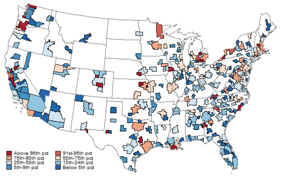

NOTE: figure/graphic rendered as an image from the PDF; its content is not machine-readable text. Caption (if any) follows as the next block.

In conclusion, I find that the data displays substantial heterogeneity in local skill

remoteness both within occupations and across locations, and within locations across

occupations. The variation in local skill remoteness reveals how jobs relate to each

other and how different cities compare in terms of their skill mix. It is this variation

that I will exploit in my subsequent analysis.

#### **3.2 Skill-remote jobs are more likely to be destroyed than skillcentral ones during recessions**

The previous section explored variation in the local skill remoteness of jobs, across

occupations and locations. I now turn to job dynamics. First, I measure the propen-

sity of workers to separate from their job, as it varies with the local skill remoteness

of their occupation and over the business cycle. In recessions, the share of work-

ers separating from locally skill-remote jobs increases disproportionately. In the

data, however, there exist virtually no difference in the re-employment probability

of workers whose last job was skill-remote or skill-central (the median unemploy-

ment duration is 12 weeks for both groups, with 1 in 4 workers in both groups having

unemployment spells of at most 4 weeks). Therefore, I conclude that locally skill-

slow-evolving objects; this is partially due to the skill data, but is also also an artifact of using OES

employment shares, which are constructed as 3-years moving averages.

Electronic copy available at: https://ssrn.com/abstract=4676763

Page 18

16

Figure 2: Percentage of workers separated from a job more locally skill remote than the

median job. This percentage increases in recessions (shaded areas). The red line is raw

monthly transitions, while the green line is smoothed through an interpolated cubic spline.

Source: CPS 1996-2017.

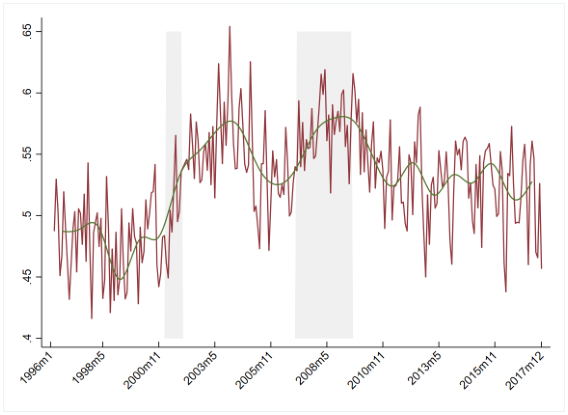

NOTE: figure/graphic rendered as an image from the PDF; its content is not machine-readable text. Caption (if any) follows as the next block.

remote jobs are more likely to be destroyed than the median job during recessions.

This fact suggests that the local skill remoteness of the last job is a potentially useful

characteristic to shed light on the cyclicality in the consequences of job loss.<sup>17</sup>

The percentage of destroyed jobs that are more locally skill-remote than the median

job increases during economic downturns. This fact is illustrated by figure 2, which

plots this percentage over time, computed as the percentage of jobs that (i) end in

separation (layoff) at month *t*, and (ii) are more locally skill remote than the median

job at month *t*. One can see that, during recessionary periods, the percentage of

17In the CPS, one can measure employment-to-unemployment transitions at the monthly fre-

quency. This implies that unemployment spells may go undetected if the separation occurs after the

interview date in month *m* but a new job is found before the interview date in the subsequent month

*m* + 1. If workers losing a skill-remote job were more likely to experience this kind of very short

unemployment spells, it would be unclear whether skill-remote jobs are more likely to be destroyed

in recessions or simply more likely to lead to longer unemployment spells. However, both the raw

data on unemployment duration, shown in appendix C (Table C.5), and the controlled evidence

on hours worked after layoff in section 4.3, provide support for the hypothesis that differences in

post-layoff re-employment rates are minimal between skill-remote and skill-central laid-off workers.

Electronic copy available at: https://ssrn.com/abstract=4676763

Page 19

17

Table 2: The percentage of destroyed jobs that are more locally skill-remote than the

median job is larger in recessions (60.3%) than in booms (46.6%). “Layoffs only” denotes

separations occurring because of (i) plant closure or plant distress, or (ii) layoff or position

abolished. CPS 1996-2017.

| % of jobs destroyed that are locally skill -remote |  |  |
| --- | --- | --- |
|  | Recessions Booms | Std Dev . . |
| Layoffs only | 55 2 49 4 . . | 2 1 . |
| All separations | 60 3 46 6 . . | 3 0 . |

NOTE: table converted from PDF layout to HTML text; cell boundaries are reconstructed. See PDF if exact alignment matters.

jobs which are more skill-remote than the median job increases.

How large is the countercyclical increase depicted in figure 2? To assess this, I regress

the percentage of lost jobs that are skill-remote on a recession indicator (based on

the NBER business cycle dates). Controls include detailed occupation fixed effects. I

find that when looking only at layoffs, the cyclical disparity is equal to 6 percentage

points and, for all separations, it is equal to approximately 14 percentage points

(respectively equivalent to about three and four times the standard deviation of the

outcome variable, see table 2). I conclude that jobs destroyed in recessions are more

likely to be locally skill-remote and this difference is economically meaningful.

### **4 Skill remoteness and post-layoff labor market out-**

### **comes**

In this section, I quantify the effect of losing a locally skill-remote job on a worker’s

post-layoff earnings, employment, and mobility. I take an empirical approach that

exploits the richness of longitudinal micro-data to estimate this effect net of unob-

served individual characteristics as much as possible.<sup>18</sup> I further use a variety of

data sources to distinguish the effect of local skill remoteness from many potential

confounders, including city size and the local density of college-educated workers.

Through a series of thoroughly controlled regressions, I find a robust, large, and per-

18The effects of the last job’s local skill remoteness on a worker’s labor market outcomes are

better identified in the case of layoffs as opposed to any type of separation. Layoffs are separation

episodes not initiated by the worker and not related to the worker’s performance or conduct on

the job, and typically identified in the data as plant closures or positions abolished. Therefore, in

layoff cases, unobserved characteristics of the separating worker are not likely to play a significant

role in the decision to terminate the employment spell.

Electronic copy available at: https://ssrn.com/abstract=4676763

Page 20

18

sistent negative association between losing a locally skill-remote job and a worker’s

post-layoff earnings. Ex ante, it needs not be so. Losing a locally skill-remote job

could have been a proxy for having experience with a unique (and, therefore, in high

demand) set of skills and tasks. However, the data does not support this interpreta-

tion. On the contrary, I find that the majority of the earnings losses associated with

layoff from a skill-remote job are accounted for by lower wages at re-employment —

themselves associated with occupational change and larger skill distance between

the new and the old job.

#### **4.1 Displaced workers in the NLSY79**

To study how the local skill remoteness affects individual labor market outcomes

after layoff, I draw on detailed individual labor market histories in the National

Longitudinal Survey of Youth 1979 (NLSY79).<sup>19</sup> The NLSY79 is a comprehensive

survey of American residents who were aged between 14 and 22 in 1979. NLSY79

respondents answer questions about current and previous jobs and, from this infor-

mation, a longitudinal record spanning from the date of the first interview through

the most current interview date is constructed for each respondent. As a result,

the NLSY79 Work History Data provides researchers with a week-by-week longitu-

dinal work record of each NLSY79 respondent.<sup>20</sup> Importantly for the purposes of

this paper, NLSY79 interviewers go to great lengths to follow individuals as they

migrate across cities. Therefore, the data allows me to study changes in local skill

remoteness that occur as individuals move across space and take different jobs in

different places.

I focus on workers who lost their job involuntarily, because of (i) plant closure or

plant distress, or (ii) layoff or position abolished (i.e., displacement episodes). In

particular, I exclude non-employment episodes that originate in a firing or a quit,

19Specifically, I use the restricted-use geo-coded version of the data to identify the respondents’

metropolitan area of residence.

20Data is available from from January 1, 1978 through December 31, 2012 (covering up to

December 2014, for the last wave). Though NLSY79 data is available since 1978, I use it only

since 1994 because in that year the survey underwent a major re-design to implement, among other

improvements, dependent-coding techniques that make employment and occupational affiliation

data significantly less prone to measurement error. Furthermore, although the data is weekly,

because respondents are interviewed once a year, changes in wages and occupational status are

often registered once or twice a year only, depending on how often the respondent changes job. To

mitigate recall bias but still offer a detailed picture of how the effect of skill remoteness changes

over time, I aggregate the panel at the monthly level.

Electronic copy available at: https://ssrn.com/abstract=4676763

Page 21

19

because, in those cases, the estimated effects of skill remoteness on post-separation

outcomes would likely be contaminated by selection on unobservables. A large and

very fruitful literature has treated displacement events as plausibly exogenous job

loss episodes, and I follow this interpretation as well.<sup>21</sup> I restrict the sample to

individuals who have complete information on their occupation and metropolitan

area (CBSA) of residence at the time of layoff, and are also observed in the sample

for at least 12 consecutive months prior to and 48 months after the job loss episode.

I exclude CBSA-occupation cells that have fewer than 5 individuals per year. I

exclude workers who, at the time of layoff, were usually employed for fewer than 35

hours per week or 50 weeks per year, working without pay, self-employed, or given

a recall notice by their employer. Of these workers, I drop those laid-off from a job

that had lasted at most 1 quarter. For all others, I use information on the occupation

and city of residence at layoff to attribute a value of local skill remoteness to each

individual according to the last job held.

When matched with the O*NET-OES derived measure of local skill-remoteness in

this way, the final sample contains 2,009 individuals, observed across 20 years, 212

metropolitan areas (CBSAs), and 22 occupational groups. The average number

of individuals per metro area is 9.5 and the average number of individuals per

a standard deviation of 1.

Laid-off workers in my NLSY79 sample are 29 to 56 years old at the time of lay-

off, and used to be employed disproportionately in Production, Transportation, and

Material Moving occupations (25%), Office and Administrative Support occupations

(20%), and Managerial and Sales occupations (15%). Layoff rates increase in re-

cession periods, as expected: 2001 accounts for almost 10% of all layoff episodes in

the sample, while the Great Recession years (2008-2009) for over 14% — an equal

and 48% has at least a high school diploma or equivalent but no college degree.

The median (mean) monthly earnings at layoff is around $2,080 ($2,540) — a little

21Specifically, Jacobson, Lalonde and Sullivan (1993), Davis and von Wachter (2011), Huckfeldt

(2021), Krolikowski (2017), Farber (2017), and Jarosch (2021) also consider exogenous job loss

episodes. In the CPS Displaced Worker Survey, displaced workers are also identified precisely as

those “who lost or left jobs because their plant or company closed or moved, or their position or

shift was abolished”. See section 5 for empirical analysis with DWS data.

Electronic copy available at: https://ssrn.com/abstract=4676763

Page 22

20

Table 3: The NLSY79 laid-off workers sample (1994-2014, metropolitan areas only)

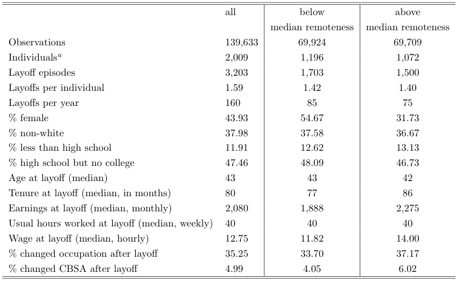

NOTE: figure/graphic rendered as an image from the PDF; its content is not machine-readable text. Caption (if any) follows as the next block.

**text found inside the figure**

all below above

median remoteness median remoteness

Observations 139,633 69,924 69,709

Individuals*<sup>a</sup>* 2,009 1,196 1,072

Layoff episodes 3,203 1,703 1,500

Layoffs per individual 1.59 1.42 1.40

Layoffs per year 160 85 75

% female 43.93 54.67 31.73

% non-white 37.98 37.58 36.67

% less than high school 11.91 12.62 13.13

% high school but no college 47.46 48.09 46.73

Age at layoff (median) 43 43 42

Tenure at layoff (median, in months) 80 77 86

Earnings at layoff (median, monthly) 2,080 1,888 2,275

Usual hours worked at layoff (median, weekly) 40 40 40

Wage at layoff (median, hourly) 12.75 11.82 14.00 % changed occupation after layoff 35.25 33.70 37.17

% changed CBSA after layoff 4.99 4.05 6.02

*a*Columns 2 and 3 do not sum to column 1 because some individuals are above median skill

remoteness for one layoff episode and below for another.

higher for workers above median skill remoteness (at $2,275), who also have some-

what longer tenure on the job, than for workers below median skill remoteness (at

$1,888). The median (mean) tenure on the job was of 80 (173) months. After layoff,

I find that 5% of the sample has moved to a different CBSA and approximately 1 in

3 workers has changed occupation. These proportions are a bit higher for workers

above median skill remoteness.

#### **4.2 Skill-remoteness and earnings**

As highlighted in much literature, displacement is followed by a significant and

persistent drop in earnings. On average, laid-off workers in the NLSY79 earn only

about 60% of their pre-displacement earnings 4 years after job loss, similarly to what

previous studies have shown (Jacobson et al., 1993; Farber, 2011, 2015, 2017; Davis

and von Wachter, 2011). In addition, I document that post-layoff earning losses are

systematically correlated with local skill remoteness at layoff.

Electronic copy available at: https://ssrn.com/abstract=4676763

Page 23

21

#### **4.2.1 Empirical design**

To investigate post-layoff earnings losses as a function of skill remoteness, I run

a fixed-effects regression of monthly individual earnings on local skill remoteness

at the time of layoff.<sup>22</sup> I consider a time frame between 12 months before and 48

months after layoff.

*earningsit* = *αi* + *β*<sup>(</sup><sup>1</sup><sup>)</sup>**X***it* + *β*<sup>(</sup><sup>2</sup><sup>)</sup>**X***it*0 + ∑<sup>48</sup>

**equation / math rendering (image)**

NOTE: contains mathematical notation; text above is the PDF text layer and symbols may be mis-extracted. Image shows the original.

*m*=−12 *<sup>γ</sup><sup>m</sup>***<sup>I</sup>**{*t*=*t*0+*m*} <sup>+ ∑</sup><sup>48</sup>

*m*=−12 *<sup>δ</sup><sup>m</sup>***<sup>I</sup>**{*t*=*t*0+*m*}<sup>above</sup>*<sup>it</sup>*0 <sup>+</sup>*<sup>ϵ</sup><sup>it</sup>*

**equation / math rendering (image)**

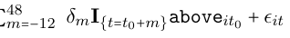

NOTE: contains mathematical notation; text above is the PDF text layer and symbols may be mis-extracted. Image shows the original.

(4)

I denote by *t*0 the month of layoff and by *i* the individual. The outcome variable

*earningsit* is monthly earnings for worker *i* in month *t*. The explanatory variable of

interest is above*it*0, an indicator that takes value 1 when worker’s *i* job at the time

of layoff *t*0 exceeded the median skill remoteness, and 0 otherwise.

I follow the literature and estimate the effect of losing a locally skill-remote job by

interacting the above*it*0 dummy with a series of time indicators that “turn on” at

different dates since layoff. In this fashion, the coefficients trace out the post-layoff

outcomes for workers as a function of their local skill remoteness at layoff, in excess

of the pure effect of time (before and after layoff). Furthermore, notice that the

regressor of interest, above*it*0 is determined by the occupation and city of residence

of worker *i* at the time of layoff. This empirical design prevents contamination of

the estimates of *δm* by occupational changes and migration episodes that happen

after layoff. Standard errors are clustered at the individual level.

My preferred regression specification includes a large variety of controls, summarized

by **X***it,***X***it*0 in (4). These include a vector of fixed effects for individual *αi*, and fixed

effects for the calendar date (month-year), the worker’s CBSA, occupation, and

industry at the time of layoff (respectively 212, 22, and 21 categories), in addition

to indicators for the month of re-employment (60 categories). The latter indicator

variable proxies for unobservables that drive unemployment duration and could

potentially confound the estimates of the coefficients of interest, *δm*.<sup>23</sup> I also include

in the control set indicators for the individual’s age, and indicators for whether

22I restrict the attention to labor income, so that earnings are zero for non-employed workers. 23A large body of literature has analyzed the prevalence and interpretation of duration de-

pendence, i.e. the negative relationship between the duration of a jobless spell and the worker’s

probability of finding new employment. Most recent studies, among which Alvarez, Borovickova,

and Shimer (2019), find that negative selection in the pool of long-term unemployed accounts for

most of this relationship, while “true” duration dependence has a negligible role. For this reason,

I control for unemployment duration using 60 dummies for the month of re-employment.

Electronic copy available at: https://ssrn.com/abstract=4676763

Page 24

22

the individual has changed occupation, industry, or metropolitan areas of residence

after layoff — following the literature that finds a significant role of such changes in

explaining post-layoff earnings losses (Neal, 1995, 1999; Huckfeldt, 2021).

Cognizant of the spatial economics literature and the important agglomeration ef-

fects it documents, I also include controls for city size, the local share of college-

educated workers, the local unemployment rate, the local share of employment in

the same occupation as the worker’s last job, and a shift-share style control that

proxies for the level of local labor demand. Finally, I also allow the effect of city

size to vary by occupation at layoff, to encompass differential agglomeration effects

by occupational groups. Including these controls nets out the effect of workers’ un-

observed characteristics that are correlated with both their location choices before

layoff and their earnings after layoff.<sup>24</sup>

#### **4.2.2 Results**

After netting out the effect of the aforementioned covariates, I find no association

between one’s job’s local skill remoteness at layoff and pre-layoff earnings. Con-

versely, the data displays a negative correlation between skill remoteness at layoff

and post-layoff monthly earnings. Figure 3 depicts the estimated earnings losses for

laid-off workers whose last job was either above (red) or below (blue) the median

local skill remoteness. Earnings losses are expressed in contemporary dollars. The

figure displays the familiar V-shaped pattern featured in all studies of post-layoff

earnings and illustrates that: (i) the effect of skill remoteness at layoff on post-layoff

earnings is negative; (ii) in contrast, a job’s local skill remoteness does not display

any effect on pre-layoff earnings.<sup>25</sup>

24Specifically, the set of geographic controls is as follows: (i) log-population, as in the 2000

Decennial Census; (ii) city-level share of college-educated workers — in the spirit of Moretti (2004;

2011); (iii) city-level share of people younger than 25 — as per the “young workers hypothesis” in

Shimer (2001); (iv) city-level unemployment rate, constructed from the Local Area Unemployment

Statistics at any date (following Davis and von Wachter, 2011); (v) the city-level employment share

of the lost job’s occupation from OES; (vi) a Bartik-style control (Bartik, 1991; Blanchard and

Katz, 1992), constructed as follows:

bartik*oct* = ∑

*c*<sup>′</sup>≠*c*

**equation / math rendering (image)**

NOTE: contains mathematical notation; text above is the PDF text layer and symbols may be mis-extracted. Image shows the original.

*ωoct*−1∆*emploc*′*t*

**equation / math rendering (image)**

NOTE: contains mathematical notation; text above is the PDF text layer and symbols may be mis-extracted. Image shows the original.

where *ωoct*−1 is the share of employment in occupation *o*, city *c*, time *t* −1, ∆indicates the first

difference time-series operator, and *c*<sup>′</sup> are all cities in the data different from *c*. Unless otherwise

noted, all control variables are computed from the monthly Current Population Survey 1994-2017.

25The precise estimates are reported in column 1 of table 4, and in greater detail in tables C.7

and C.8 in Appendix C.5, which also reports the same graph and tables in percentage terms as

Electronic copy available at: https://ssrn.com/abstract=4676763

Page 25

23

Figure 3: Regression (4): skill remoteness at layoff is *negatively* associated with

monthly earnings after layoff. Overall, in the course of 4 years after layoff, workers

who were laid-off from a locally skill-remote job earn over $10,000 less than workers

who were laid-off from a locally skill-cebntral job. Source: NLSY79, laid-off workers

sample, 1994-2014.

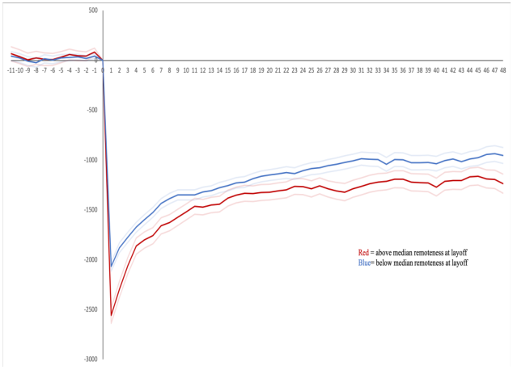

NOTE: figure/graphic rendered as an image from the PDF; its content is not machine-readable text. Caption (if any) follows as the next block.

The difference in post-layoff earnings between skill-remote and skill-central work-

ers is substantial. In the month of layoff, the earnings of workers whose last job

was locally skill-remote are on average $491.18 lower than workers whose last job

was locally skill-central (about 25% larger of the estimated baseline loss, which is

$2067.58 at *t*0). The difference is still economically and statistically significant until

4 years after job loss and stable at around $200 per month. At 6 months since layoff,

workers who lost a skill-remote job earn $224 per month less than those who lost

at skill central one. At 12 (24, 36, 47) months, the difference is about $142 ($202,

$196, $283), hovering between 15% and 20% of baseline estimated losses.<sup>26</sup> Overall,

a fraction of estimated pre-layoff average earnings for both workers who lost a skill-central or a

skill-remote job(figure C.2, tables C.9), C.10.

26I also test for increasingly negative effect as the lost job exceeds higher levels of local skill

remoteness. Appendix table C.11 report coefficients from regression (4), but using indicators for

the job exceeding the 75th, 90th, and 50th percentile (the baseline). Negative effects associated

Electronic copy available at: https://ssrn.com/abstract=4676763

Page 26

24

in the course of 4 years after layoff, workers who were laid-off from a locally skill-

remote job earn an estimated $10,111.49 *less* than workers who were laid-off from a

locally skill-central job — approximately 5 months of the median worker’s pre-layoff

income. On average, the earnings losses after layoff are 17.7% larger for skill-remote

workers over a 4-years period (see table C.7 and C.8 in Appendix C.5).<sup>27</sup>

#### **4.3 Hours worked and wages at re-employment**

Losing a skill-remote job is associated with larger earning losses than losing a skill-

central one. In this section, I ask whether the robust negative association between

skill remoteness at layoff and earnings after layoff is due to lower hours worked be-

cause of non-employment or under-employment, or rather lower wage rates upon

re-employment. I find that lower wages account for practically the entirety of earn-

ings losses associated with local skill remoteness. The data does not support the

hypothesis of more persistent or frequent non-employment episodes for workers who

lost a skill-remote job vis-a-vis those who lost a skill-central one.

To show how the extensive and intensive margins of employment affect post-layoff

earnings, I articulate my empirical strategy across two different regressions and

report the resulting estimates in table 4 columns 2 and 3. The first of these two

columns depicts the estimated coefficients from a fixed effects regression where the

outcome is hours worked at various dates after layoff, which are equal to 0 when non-

employed. Column 3, on the other hand, reports the estimates from a similar fixed

effects specification that studies hourly wages after layoff. The empirical design is

identical to the earnings regression (4), with all controls included. Standard errors

with losing a job exceeding higher skill remoteness percentiles are larger than those associated with

losing a job which is more skill-remote than the median.

27Everything else equal, a smaller share of local jobs in the exact same occupation as the lost

job can exacerbate the negative earnings effects associated with local skill remoteness. In a regres-

sion specification in which the local skill remoteness and the employment share of the lost job’s

occupation are *both* included, and interacted with time dummies, I find that there is a significant

negative earnings effect of losing a job in a city where the lost job’s occupation is a smaller share of

total employment. This effect is distinct from the earnings losses associated with skill remoteness

at layoff, which are large and precisely estimated also in this augmented specification. See table

C.12.

Electronic copy available at: https://ssrn.com/abstract=4676763

Page 27

25

Table 4: Higher skill remoteness at layoff is associated with lower earnings after layoff (column

1). The data does not support a negative effect on hours worked, however, so that earnings losses

are mostly accounted for by lower wages at re-employment (columns 2 and 3). Monetary values

are in contemporary dollars; variables are at monthly frequency unless otherwise specified. Source:

NLSY79, laid-off workers sample, 1994-2014.

| t | Earnings | Hours worked | Hourly Wage |
| --- | --- | --- | --- |
| 6 - | 616 . | 012 -. | 033 - . |
|  | (6021) . | (275) . | (030) . |
| 1 - | 4171 . | 030 - . | 002 . |
|  | (4902) . | (144) . | (018) . |
| 0 | 49118 - . | 162 - . | 194 - . |
|  | (7834) . | (261) . | (040) . |
| 1 | 41653 - . | 101 - . | 154 - . |
|  | (8053) . | (279) . | (041) . |
| 2 | 28551 - . | 095 . | 117 - . |
|  | (8166) . | (289) . | (040) . |
| 3 | 18934 - . | 473 . | 062 - . |
|  | (8183) . | (294) . | (041) . |
| 6 | 22399 - . | 131 - . | 082 - . |
|  | (8174) . | (2 92) - | (040) . |
| 9 | 17128 - . | 321 . | 063 - . |
|  | (8001) . | (296) . | (039) . |
| 12 | 14276 - . | 524 . | 052 - . |
|  | (7625) . | (289) . | (037) . |
| 18 | 16170 - . | 050 . | 078 - . |
|  | (7983) . | (305) . | (039) . |
| 24 | 20237 - . | 006 - . | 100 - . |
|  | (8071) . | (307) . | (040) . |
| 30 | 27814 - . | 191 - . | 134 - . |
|  | (8461) . | (313) . | (041) . |
| 36 | 19612 - . | 073 . | 088 - . |
|  | (8762) . | (337) . . | (043) . |
| 42 | 19155 - . | 076 - . | 097 - . |
|  | (9001) . | (339) . | (043) . |
| 47 | 28367 - . | 284 - . | 116 - . |
|  | (9559) . | (349) . | (044) . |
| Cumulative earnings loss | 1011149 - , . | – | – |
| Controls | age geographic confounders mobility indicators , , |  |  |
| FE | individual , | time occupation, industry, city, re-empl month , . |  |
| N | 124199 , | 124199 , | 124199 , |
| R2 (within) | 036 . | 039 . | 029 . |

NOTE: table converted from PDF layout to HTML text; cell boundaries are reconstructed. See PDF if exact alignment matters.

Electronic copy available at: https://ssrn.com/abstract=4676763

Page 28

26

are clustered at the individual level.<sup>28</sup>

*hit* = *αi* + *β*<sup>(</sup><sup>1</sup><sup>)</sup>**X***it* + *β*<sup>(</sup><sup>2</sup><sup>)</sup>**X***it*0 + ∑<sup>48</sup>

**equation / math rendering (image)**

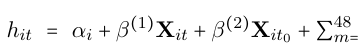

NOTE: contains mathematical notation; text above is the PDF text layer and symbols may be mis-extracted. Image shows the original.

*m*=−12 *<sup>γ</sup><sup>m</sup>***<sup>I</sup>**{*t*=*t*0+*m*} <sup>+ ∑</sup><sup>48</sup>

*m*=−12 *<sup>δ</sup><sup>m</sup>***<sup>I</sup>**{*t*=*t*0+*m*}<sup>above</sup>*<sup>it</sup>*0 <sup>+</sup>*<sup>ϵ</sup><sup>it</sup>*

**equation / math rendering (image)**

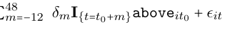

NOTE: contains mathematical notation; text above is the PDF text layer and symbols may be mis-extracted. Image shows the original.

(5)

*wit* = *αi* + *β*<sup>(</sup><sup>1</sup><sup>)</sup>**X***it* + *β*<sup>(</sup><sup>2</sup><sup>)</sup>**X***it*0 + ∑<sup>48</sup>

**equation / math rendering (image)**

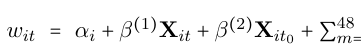

NOTE: contains mathematical notation; text above is the PDF text layer and symbols may be mis-extracted. Image shows the original.

*m*=−12 *<sup>γ</sup><sup>m</sup>***<sup>I</sup>**{*t*=*t*0+*m*} <sup>+ ∑</sup><sup>48</sup>

*m*=−12 *<sup>δ</sup><sup>m</sup>***<sup>I</sup>**{*t*=*t*0+*m*}<sup>above</sup>*<sup>it</sup>*0 <sup>+</sup>*<sup>ϵ</sup><sup>it</sup>*

**equation / math rendering (image)**

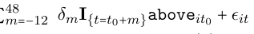

NOTE: contains mathematical notation; text above is the PDF text layer and symbols may be mis-extracted. Image shows the original.

(6)

The results from estimating regression (5) are consistent with no meaningfully differ-

ential reduction in hours worked for workers who lost a skill-remote job with respect

to those who lost a skill-central one.<sup>29</sup> On the contrary, workers who lost a locally

skill-remote job earn persistently less per hour than workers who lost a skill-central

job, and this effect is precisely estimated for at least 48 months since layoff.

As in the earnings regression, there is no association between hourly wage rates

before layoff and local skill remoteness at layoff. However, the coefficients becomes

negative after layoff, and is equal to -1.94 dollars per hour in the month of layoff.

Therefore, losing a locally skill-remote job implies a drop of 14.4% with respect to

skill remoteness at layoff is still significant in the four years after layoff and equals

on average to -0.95 dollars per hour. For the median worker, who in this sample

works 40 hours per week and 52 weeks per year, this translates in a persistent drop in

total yearly wages of almost $8,000 over four years (a large portion of the cumulative

$10,000 estimated earnings losses).

#### **4.4 Career changes and migration rates**

#### **4.4.1 Occupational mobility**

Evidence from laid-off workers in the NLSY79 shows that workers displaced from

a locally skill-remote job tend to have lower wages at re-employment than workers

who lost a skill-central job. In addition, much literature emphasizes how changing

28I also run a logit specification where the outcome variable is the individual probability of being

employed at any date after layoff and come to the same conclusion, that is, there is no apparent

association between post-layoff employment rates and local skill remoteness at layoff.

29It bears noting that the estimated regression does predict a significant reduction in hours

worked after layoff, just not as a function of the local skill remoteness of the lost job.

occupation affects wage levels and wage growth over the life-cycle and after dis-

placement episodes (Kambourov and Manovskii, 2008; Gathmann and Sch¨onberg,

2010; Huckfeldt, 2021). Motivated by these findings, I investigate two aspects of

the re-employment job that may account for wage disparities between skill-remote

and skill-central workers: the job’s occupation, and the new job’s skill distance from

the old one. I find that skill-remote laid-off workers, with respect to skill-central

ones, are (i) more likely to change occupation after layoff and (ii) more likely to be

re-employed in a job that is “far” from the lost one in the skill space.

Skill remoteness at layoff is associated with increased and more meaningful occupa-

tional mobility. To show this, my empirical strategy consists of two regressions: the

first one studies the propensity to work in a different 2-digit occupation than at time

of layoff at any of the first 48 months *after layoff*. I construct first a set of 48 indi-

cators change*it* for *t* = 0*,*1*,*2*,*3*,...,*47. These variables take value 0 if the workers

is employed in the same occupation she had before layoff at *t* = 1*,*2*,*3*,...,*47, and 1

otherwise. (Recall that *t* = 0 indicates the month when layoff occurred.) I then use a

linear probability specification and follow the empirical design in equation (4) when

it comes to the independent variable and covariates. The estimated coefficients are

On average, workers who lost a skill-remote job are 11% more likely to change oc-

cupation after layoff than workers who lost a skill-central job. This difference is

economically and statistically significant until 48 months after layoff. At that time

63% of those laid-off from a skill-remote job are employed in a different occupation

than the lost job, vis-a-vis 57% of those laid-off from a skill-central job.<sup>30</sup>

Occupational changes are more prevalent among workers who lost a skill-remote job

than those who lost a skill-central one. But how substantial are these occupational

changes? I now investigate the extent to which a change in occupational affiliation

represents a significant change in the skills the worker uses in her job and whether

more significant changes are more likely for skill-remote than for skill-central work-

ers. To do so, I compute skill distances between occupations from O*NET data

following equation (1). I first calculate the distance between occupation *o*, the oc-

30A few clarifications about figure 4: (i) the depicted propensity is cumulative, that is, a worker

who changed occupation at month 1 and has not returned to her pre-layoff occupation at month 2

(3, 4, . . . ) will be counted as a “switcher” at month 1 and 2 (and 3, 4, . . . ) as long as she does

not switch back to the pre-layoff occupation — a phenomenon that does not appear common in the

data. (ii) The sample selection is such that workers are required to be in the same job pre-layoff

for at least a quarter, so that is why estimates of occupational change pre-layoff are not available.

Figure 4: Higher skill remoteness at layoff is associated with a higher propensity

to change occupation after layoff. Source: NLSY79, laid-off workers sample, 1994-

2014.

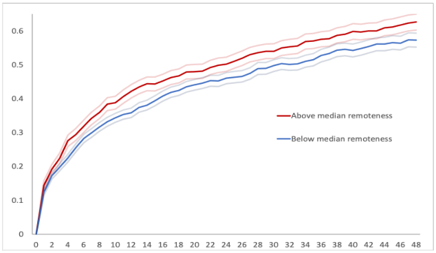

NOTE: figure/graphic rendered as an image from the PDF; its content is not machine-readable text. Caption (if any) follows as the next block.

cupation associated with the lost job, and occupation *o*<sup>′</sup>, the occupation associated

with the job at re-employment. I do so for each individual in my NLSY79 sample

who has changed occupation following layoff. For ease of interpretation, I standard-

ize the distance so that it has unit standard deviation and denote it by *d<sup>std</sup>*

*oo*<sup>′</sup><sup>(</sup>*<sup>i</sup>*<sup>)</sup><sup>.</sup>

**equation / math rendering (image)**

NOTE: contains mathematical notation; text above is the PDF text layer and symbols may be mis-extracted. Image shows the original.

Then, I run a linear regression of the standardized distance *d<sup>std</sup>*

*oo*<sup>′</sup><sup>(</sup>*<sup>i</sup>*<sup>)</sup> <sup>on</sup> <sup>an</sup> <sup>extensive</sup>

set of fixed effects **I***it* for year, metro-area, industry, occupation, sex, race, age, edu-

cation, and marital status, and the local unemployment rate *uc*(*i*)*t*, plus an indicator

variable above*it*0 that takes value 1 if the worker’s lost job was more skill-remote

than the median one at the time of layoff.<sup>31</sup>

*d<sup>std</sup>*

**equation / math rendering (image)**

NOTE: contains mathematical notation; text above is the PDF text layer and symbols may be mis-extracted. Image shows the original.

*oo*<sup>′</sup>*t*<sup>(</sup>*<sup>i</sup>*<sup>)</sup> <sup>=</sup> *<sup>α</sup>***<sup>I</sup>***<sup>it</sup>*<sup>+</sup>*<sup>βu</sup><sup>c</sup>*<sup>(</sup>*<sup>i</sup>*<sup>)</sup>*<sup>t</sup>* <sup>+</sup>*<sup>γ</sup>*<sup>above</sup>*<sup>it</sup>*0 <sup>+</sup>*<sup>ϵ</sup><sup>it</sup>* (7)

**equation / math rendering (image)**

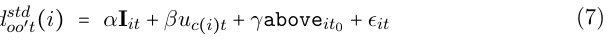

NOTE: contains mathematical notation; text above is the PDF text layer and symbols may be mis-extracted. Image shows the original.

The effect of skill remoteness at layoff on the skill distance at re-employment corre-

sponds to the coefficient *γ* in (7). I find that it is equal to 0.242, and statistically

and economically significant (standard error equal to 0.0241). I then compare con-

ditional means from regression’s (7) to unconditional ones, as depicted in table 5.

The skill distance between the old and the new occupation is, for workers who lost

31Errors are clustered at the cbsa-year level.

up, not only are skill-remote workers more likely to change career after layoff, but

they are also more likely to do so going through substantial skill portfolio changes,

“traveling” a larger distance in the skill space between the old and new job.

Table 5: Higher skill remoteness at layoff is associated with larger skill distance between the

old and new job at re-employment. Source: NLSY79, laid-off workers sample, 1994-2014.

| dstd(i) oo′ | group | value | SD/SE |
| --- | --- | --- | --- |
| unconditional mean | all workers | 0 981 . | 1 |
| unconditional mean | occupational switchers | 1 576 . | 0 833 . |
| conditional mean from (7) | occupational switchers skill -central , | 1 433 . | 0 144 . |
| conditional mean from (7) | occupational switchers skill -remote , | 1 675 . | 0 161 . |

NOTE: table converted from PDF layout to HTML text; cell boundaries are reconstructed. See PDF if exact alignment matters.

Does the skill distance between the old and the new job explain some of the earn-

ings losses documented in 4.2.2? The data suggests a positive answer, though the

results are noisier (and the sample smaller) than in previous sections. To get at

this conclusion I run the following empirical specification on the sample of occupa-

tional switchers. As usual, I consider a time frame between 12 months before and

48 months after layoff.

*earningsit* = *αi* + *β*<sup>(</sup><sup>1</sup><sup>)</sup>**X***it* + *β*<sup>(</sup><sup>2</sup><sup>)</sup>**X***it*0 + ∑<sup>48</sup>

**equation / math rendering (image)**

NOTE: contains mathematical notation; text above is the PDF text layer and symbols may be mis-extracted. Image shows the original.

*m*=−12 *<sup>γ</sup><sup>m</sup>***<sup>I</sup>**{*t*=*t*0+*m*} <sup>+ ∑</sup><sup>48</sup>

*m*=−12 *<sup>δ</sup><sup>m</sup>***<sup>I</sup>**{*t*=*t*0+*m*}<sup>exceed</sup>*<sup>it</sup>* <sup>+</sup>*<sup>ϵ</sup><sup>it</sup>*

**equation / math rendering (image)**

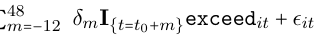

NOTE: contains mathematical notation; text above is the PDF text layer and symbols may be mis-extracted. Image shows the original.

(8)

I denote by *tc* the month in which worker *i* changed occupation after layoff. The

outcome variable *earningsit* is monthly earnings for worker *i* in month *t* (before

and after switching occupation). The explanatory variable of interest is exceed*it*,

an indicator that takes value 1 when the distance between the job *i* held at *t*0 (the

“old” job) and the one she holds at *t* (the “new” job, which started at *tc*) exceeds

the median skill distance for job switchers.<sup>32</sup> I find that the coefficients *δm* are

negative (higher distance between the old and new jobs is associated with lower

earnings) and, in magnitude, equal to approximately a third of the coefficients on

local skill remoteness estimated in Table 4. In other words, a new job exceeding

median skill distance is associated with an average loss of $60 per month (vis-a-

vis an average loss of $200 per month associated with the old job being above

median skill remoteness at layoff). I conclude that skill-remote workers who change

occupation after layoff on average “travel” a greater distance in the skill space at

32This specification is identical to 4 when it comes to controls and the independent variable, but

the explanatory variable and the underlying sample are different.

re-employment. This may account for up to 30% of the overall earnings losses

associated with local skill remoteness at layoff — with the caveat that coefficients

on skill distance are estimated with noise and often are not statistically significant.

#### **4.4.2 Migration**

In addition to occupational change, migration represents an important margin of

gone a displacement episode in the NLSY79 has changed their metropolitan area of

residence (CBSA/CBSA) in the 4 years after layoff. This is a considerably higher

share than in the general population — whose ratio is less than 1 in 20 in a 4-

years period. Further, I find that workers who lost a locally skill-remote job are

more likely to change their metro-area of residence after layoff than those who lost

a locally skill-central job. Finally, migration leads to a decrease in workers’ local

skill remoteness. This drop is larger the larger was a worker’s local skill remoteness

at layoff. I interpret these results as evidence that migration is directed; workers

recognize how the human capital accumulated in their previous job may be less

skill-remote in local labor markets other than their current one, and migrate across

cities accordingly.

There is a positive association between the local skill remoteness of the lost job

and the propensity to migrate to a different metro-area after layoff. To show this,

I construct an indicator variable that takes value 1 if the worker ever changes her

metro-area of residence in the first 48 months after layoff. I then use a linear

probability model to investigate the relationship between the propensity to migrate

and local skill remoteness at layoff. The control set includes a rich set of fixed effects

**I***it* for year, metro-area, industry, occupation, sex, race, age, education, marital

status, and the local unemployment rate in the origin city. Errors are clustered

at the metro area, year level. I find that losing a job above local median skill

remoteness increases the probability of migrating to another metro area by about

33This effect is quite sizable and equal to a bit less than half of the change associated with being

married (-0.049) and about 6% of the change associated with a one percentage point increase in the

local unemployment rate (-0.373). An alternative and slightly different empirical design regresses

migration dummies at all dates after layoff on the interaction of time after layoff and a continuous

measure of local skill remoteness at layoff. This returns similar results, with coefficients ranging

Figure 5: Higher skill remoteness at layoff is associated with a higher propensity to

move across space after layoff. Source: NLSY79, laid-off workers sample, 1994-2014.

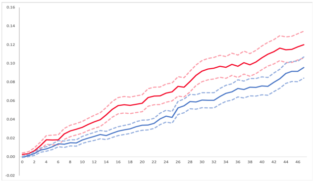

NOTE: figure/graphic rendered as an image from the PDF; its content is not machine-readable text. Caption (if any) follows as the next block.

If post-layoff mobility over space is directed, we expect that workers on average move

to cities where the skills accumulated in their previous occupation are less remote

than in the current metro area. To verify this hypothesis, I compute the change

in local skill remoteness that results from a move across two different metropolitan

areas. Specifically, I first consider the local skill remoteness of the lost job in the city

where the job was originally located. Then, I investigate the local skill remoteness

of the lost job after migration — that is, in the new city.<sup>34</sup> I finally correlate the

percentage change in the lost job’s skill remoteness across the two locations with

the level of skill remoteness at layoff.

On average, workers who migrate after layoff tend to reduce their occupation’s skill

remoteness: the average drop is equal to 13.7% for the sample of laid-off migrants.

Furthermore, the post-migration decreases in local skill remoteness are larger in

absolute value the higher that the value of local skill remoteness was at layoff. In

other words, workers who lose a job more skill-remote than the median tend to

reduce their level of local skill remoteness after migration by a *larger* percentage

than those who lost a job less skill-remote than the median. To show this, I regress

34Notice that I keep the job’s occupation fixed (at *t* = 0, the month of displacement), so this

difference can be computed regardless of whether the worker is re-employed in the new city.

the percentage change in the lost job’s skill remoteness across the two locations on

a dummy that takes value 1 if the lost job was more skill remote than the median

at the time and location of layoff (above*it*). The control set includes fixed effects **I***it* for year, metro-area, industry, occupation, sex, race, age, education, marital status,

and the local unemployment rate in the origin city. Errors are clustered at the

metro area, year level. I find that skill-remote workers who migrate to a different

metropolitan area tend to lower their old job’s local skill remoteness by about 35%

(with an estimated standard error of 2.4%).

Of those workers who change city, approximately 1 in 2 also change occupation.

For these, the total change in remoteness is the sum of two components. First, the

change in local skill remoteness of the old occupation between the old and new city,

the “spatial component”. Second, the change in local skill remoteness between the

old and the new occupation in the new city, the “occupational component”. Then,

the overall change in local skill remoteness can be written as follows, where “prime”

denotes post-migration variables:

R*oc* −R*o*<sup>′</sup>*c*<sup>′</sup> =

**equation / math rendering (image)**

NOTE: contains mathematical notation; text above is the PDF text layer and symbols may be mis-extracted. Image shows the original.

= (R*oc* −R*oc*<sup>′</sup>) −(R*o*<sup>′</sup>*c*<sup>′</sup> −R*oc*<sup>′</sup>)

**equation / math rendering (image)**

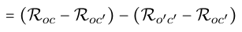

NOTE: contains mathematical notation; text above is the PDF text layer and symbols may be mis-extracted. Image shows the original.

= *spatial* + *occupational*

**equation / math rendering (image)**

NOTE: contains mathematical notation; text above is the PDF text layer and symbols may be mis-extracted. Image shows the original.

On average, the spatial component (R*oc* −R*oc*<sup>′</sup>) accounts for 40% of the overall

decline.<sup>35</sup>

The observed declines are significantly larger than what would be implied by a

mechanical “regression to the mean” effect. I compare the changes in the data

with the counterfactual changes that would occur if, instead of actual migration

patterns, I considered fictitious migration propensities based only on the distribution

of population across metro areas (“random” migration). The linear projection under

random migration has an estimated slope of -0.010 (a drop of 1%), with a standard

error of 0.003 (0.3%). Clearly, the slope under the random migration scenario is an

order of magnitude smaller than in the data, therefore I conclude that the negative

35This, however, masks a much more varied distribution, with multiple relative peaks. Approxi-

mately 15 percent of migrants experiences a contribution from the spatial component of either 20%

or 60%, and up to 12 percent of either 5% or 95% (for a full distribution, see figure C.1 in Appendix

C.4).

relationship between skill remoteness at layoff and post-migration changes is not

accounted for by regression to the mean.<sup>36</sup>

### **5 Robustness**

#### **5.1 Displaced workers in the CPS-DWS**

An additional data source to study post-layoff labor market outcomes is the Current

Population Survey’s Displaced Workers Survey (CPS-DWS). A yearly supplement to

the basic monthly CPS survey, the CPS-DWS identifies workers who were separated

from their jobs because of layoff in the previous 36 months and asks them several

questions about the lost job and, if they have one, the current job. I used information

on pre-layoff occupation and city of residence, together with earnings before and

after layoff, to estimate the effect of losing a locally skill-remote job on earnings

after layoff. The CPS-DWS has the disadvantage of not being a “true” panel since

it records pre- and post-layoff earnings at fixed intervals (at 12, 24, or 36 months,

to be precise) in a single interview, rather than monthly as the NLSY79 does.

Nevertheless, it has a large sample size and can provide an additional piece of

evidence on the role of local skill remoteness in the consequences of layoff.

My empirical specification for the CPS-DWS is similar to equation (4), with the

control set including fixed effects for state, industry, and occupation at the time

of layoff, demographics such as sex, marital status, race, Hispanic ethnicity, and

education (4 categories), in addition to an indicator for being displaced during a

recession, and the log-population of the city of residence at the time of layoff. Stan-

dard errors are clustered at level of the city of residence at the time of layoff (*c*(*i*)*t*0).

The outcome variable is the percentage change in earnings at 12, 24, or 36 months

after layoff, in terms of pre-layoff earnings. The explanatory variable of interest is

36To understand better the comparison between actual and counterfactual migration patterns,

here I detail how I construct the fictitious random migration scenario in three steps. First, I compute

the probability of moving to city *c* as the share of overall population that lives in *c*. This assumption

captures the stylized fact that larger cities attract more migrants on average. Then, I calculate the

distribution of post-migration skill remoteness as a weighted average of local skill remoteness across

all metro areas, where the weights are equal to the fictitious propensities to migrate computed in

the previous step. Finally, I compare the implied changes in remoteness under random migration

with the changes in the data. Under random migration, we see a much less significant negative

relationship between local skill remoteness at layoff and post-migration changes than under actual

migration patterns. I interpret this result as evidence that migration is directed and that skill

remoteness at layoff is an important determinant of migration patterns for laid-off workers.

the interaction between an indicator for being at 12, 24, or 36 months after lay-

off (**I**{*t*=*t*0+*m*}) and an indicator for losing a job more locally skill-remote than the

median job at the time of layoff (above*it*0). This specification, modeled after (Huck-

feldt, 2021), is illustrated in equation (9). The resulting coefficients are reported in

table 6.

∆*earningsi,t*−*t*0 = *µ* + *β*<sup>(</sup><sup>1</sup><sup>)</sup>**X***it* + *β*<sup>(</sup><sup>2</sup><sup>)</sup>**X***it*0 + ∑<sup>48</sup>

**equation / math rendering (image)**

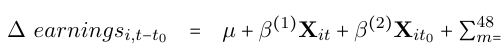

NOTE: contains mathematical notation; text above is the PDF text layer and symbols may be mis-extracted. Image shows the original.

*m*=−12 *<sup>γ</sup><sup>m</sup>***<sup>I</sup>**{*t*=*t*0+*m*} +∑*m*∈{12*,*24*,*36} *δm***I**{*t*=*t*0+*m*}above*it*0 + *ϵc*(*i*)*t*0

**equation / math rendering (image)**

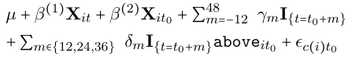

NOTE: contains mathematical notation; text above is the PDF text layer and symbols may be mis-extracted. Image shows the original.

(9)

My findings are consistent with a negative association between local skill remoteness

at layoff and post-layoff earnings. In particular, displaced workers whose last job

was above median local skill remoteness earn between 6.9% and 8.6% less, in terms

of pre-layoff earnings, than comparable workers whose last job was below median

skill remoteness. The estimated losses from the NLSY analysis are comparable in

fact that losing a locally skill-remote job leads to persistently lower earnings after

layoff.

Table 6: Displaced workers whose last job was above median local skill remoteness

earn less after layoff than comparable workers whose last job was below median skill

remoteness. Estimated losses as a percentage of pre-layoff earnings. Column (1)-

(3): CPS Displaced Workers Survey 1996-2017, N=13,626. Last column: NLSY79

laid-off workers sample, 1994-2014, N=2,009.

| months after layoff | skill -central | skill -remote | difference | difference |
| --- | --- | --- | --- | --- |
|  |  |  | DWS | NLSY |
| 12 | 0324 - . | 0410 - . | 0086 . | 0051 . |
|  | (0062) . | (0018) . | (0065) . | (0030) . |
| 24 | 0156 - . | 0227 - . | 0071 . | 0076 . |
|  | (0022) . | (0024) . | (0033) . | (0035) . |
| 36 | 0031 - . | 0100 - . | 0069 . | 0074 . |
|  | (0024) . | (0029) . | (0038) . | (0037) . |

NOTE: table converted from PDF layout to HTML text; cell boundaries are reconstructed. See PDF if exact alignment matters.

#### **5.2 Selection on unobservables**

There is a concern that skill-remote and skill-central workers differ in unobservable

dimensions that are correlated with wage and mobility outcomes. If this were true,

the results of my regressions would reflect the effect of such unobservables, and

not local skill remoteness. To fix ideas, it is helpful to think of this unobservable

characteristic as “ability”.

I investigate this issue in three ways. I include in my baseline regression spec-

ifications individual fixed effects and an extensive set of controls for observable

characteristics that could lead to selection. For example, I use fixed effects for city,

industry, occupation, and the time and month of re-employment. I also control for

several characteristics of displaced workers’ cities and occupations that have been

shown in the literature to lead to sorting over space (namely, city size — allowed to

vary by occupational groups —, the share of college-educated people, the share of

workers in the same occupational groups). Any unobservable dimension of relevance

must be orthogonal to these individual and aggregate factors and still be able to

drive selection.

Secondly, while a simple unobserved ability selection story may fit the earnings re-

sults in figure 3, the intuition for why lower ability workers might migrate and change

occupation more often is less clear-cut. After all, for intrinsically less productive

workers, the benefit of migration or occupational change is likely to be limited. If

the skill remoteness of the lost job is a proxy for worker’s quality, shouldn’t we find,

then, that skill-remote workers migrate and change occupation *less* often than skill

central ones? Therefore, not only the suspected unobservable variable has to be

orthogonal to all the observable factors included in the regression, it also has to be

able to convincingly explain the wage, employment, and mobility patterns *jointly*

over time. I find that such a factor is hard to identify with confidence.

Finally, I explicitly look for evidence in favor of omitted variable bias in the NLSY79

and find none. Specifically, I correlate the residuals from a Mincerian regression of

wage levels and year-over-year wage growth with the value of local skill remoteness

for each worker. There is no correlation between either of the two residualized wage

measures and the local skill remoteness of the lost job — as one could subsume from

the absence of a relationship between earnings and local skill remoteness *before* layoff

(see figure 3). Even though one cannot exclude it *ex ante*, therefore, the data does

not support the presence of a significant omitted variable problem that biases the

association between skill remoteness at layoff and post-layoff wages and reallocation

patterns.

### **6 Concluding remarks**

By all accounts, job loss is a traumatic experience that has profound repercussions on

the involved worker’s ability to find meaningful employment, her earning capacity,

and even her health and life satisfaction. The large, negative, and persistent con-

sequences of layoff represent a substantial puzzle in our understanding of the labor

market, and a significant challenge to policy makers tasked with improving laid-off

workers’ well-being. There is ample evidence of both pecuniary and non-pecuniary

losses: Davis and von Wachter (2011) show that displaced workers lose between 1.4

and 2.8 years of pre-displacement earnings over a 20 years horizon. Sullivan and von

Wachter (2009) also point out that “job displacement leads to a 15-20% increase in

death rates during the following 20 years”. All of these effects are more pronounced

for workers laid-off in recessions (Davis and von Wachter, 2011). Much literature

investigates why. Several convincing explanations point to job-level factors, such as

occupational change, employer-specific human capital, or match quality (Huckfeldt,

2021; Jarosch, 2021; Lachowska et al., 2020). This paper offers another potential,

complementary factor: the local skill remoteness of a worker’s last job.

Local skill remoteness measures the degree of dissimilarity between the skill profiles

of a worker’s pre-displacement job and all other jobs in a local labor market. There-

fore, the measure incorporates two dimensions of heterogeneity that plausibly affect

worker reallocation after displacement: (1) differences in the skill content of jobs

that make workers with different occupational backgrounds imperfect substitutes;

and (2) heterogeneity in the availability of suitable jobs across different geographical

locations, as the literature on spatial specialization patterns and costly geographic

mobility maintains.

The skill remoteness measure I propose emphasizes that skill disparities between

workers and local jobs are an important source of frictions to worker reallocation

and, as such, affect labor market outcomes for laid-off workers along multiple di-

mensions. However, differences in skill profiles are not the only factors that affect

worker reallocation across occupations and locations. Recent literature suggests that

occupational licensing is common in the U.S., raising concerns about its effect on

employment, especially for low-skilled workers (Mulholland and Young, 2016). Since

licensing requirements vary across states, a combined study of licensing regulations

and local skill structure differences is a promising avenue for future research.

My measure of local skill remoteness proves empirically successful in accounting for

the severity and cyclicality of earnings losses for displaced workers. In particular, I

provide evidence that workers who are displaced from a locally skill-remote job have

persistently lower earnings and a lower probability to be re-employed at jobs with

similar skill profiles, with respect to comparable workers who lost a locally skill-

central job. The difference is large, about $10,000 over 4 years or 5 months of the

median worker’s pre-layoff earnings. I also show that jobs destroyed in recessions

are 30% more likely to be locally skill-remote than those destroyed in booms. I

conclude that, on average, it is precisely the jobs destroyed in downturns — i.e,

the locally skill-remote ones — that lead to the most severe earnings losses for the

workers who used to be employed in them.

Emphasizing the role of jobs’ local skill remoteness represents a step forward in our

understanding of job loss in at least two ways. First, it provides explicit evidence

of the role played by the local jobs’ skill mix. Since both a worker’s skills and

her location are concrete characteristics amenable to policy action, I believe this is

progress. Skills can be practiced and taught; with appropriate training, a worker’s

skill portfolio can reach beyond whatever her previous job entailed — presumably

improving her earnings potential. Furthermore, incentives to relocation can be eval-

uated further in the light of how a job’s *local* skill remoteness affects workers tied-in

into a specific location by other frictions (for example, financial ones).

Second, documenting the importance of the last job’s local skill remoteness also

redirects the spotlight on the characteristics of jobs, rather than workers. This

is helpful because it can help identify at-risk individuals, before such risk mate-

rializes. As shown by previous work, structural transformation disproportionately

occurs during recessions (Autor et al., 2003; Jaimovich and Siu, 2020). That jobs de-

stroyed in recession are disproportionately skill-remote can be interpreted as another

manifestation of this phenomenon. In the data, jobs are not destroyed at random:

it is precisely those whose skill profile is locally “remote” that are at higher risk of

dissolution. This, in turn, is associated with more negative earnings consequences

for workers. Crucially, locally skill-remote jobs — and the workers employed in

them — can be identified as vulnerable by observing the skills they entail and those

utilized by other jobs in the same location. While it is beyond the scope of this

paper to test specific policies predicated on the local skill remoteness of jobs, the

evidence I provide is potentially useful to outline effective and targeted labor market

policies, especially by local decision-makers.

### **References**

#### **Alvarez, Fernando E, Katar´ına Boroviˇckov´a, and Robert Shimer**, “Decom-

posing duration dependence in a stopping time model,” *Working paper*, 2019.

#### **Andersson, Fredrik, John C Haltiwanger, Mark J Kutzbach, Henry O**

**Pollakowski, and Daniel H Weinberg**, “Job Displacement and the Duration of

Joblessness: The Role of Spatial Mismatch,” *Review of Economics and Statistics*,

2018, *100* (2), 203–218.

**Autor, David H, Frank Levy, and Richard J Murnane**, “The Skill Content of

Recent Technological Change: An Empirical Exploration,” *The Quarterly Journal*

*of Economics*, 2003, *118* (4), 1279–1333.

**Bartik, Timothy J.**, *Who Benefits from State and Local Economic Development*

*Policies?*, W.E. Upjohn Institute, 1991.

**Blanchard, Olivier Jean and Lawrence F. Katz**, “Regional Evolutions,”

*Brookings Papers on Economic Activity*, 1992, *1992* (1), 1–75.

**Davis, Donald R and Jonathan I Dingel**, “A Spatial Knowledge Economy,”

*American Economic Review*, 2019, *109* (1), 153–70.

**Davis, Donald R. and Jonathan I. Dingel**, “The comparative advantage of

cities,” *Journal of International Economics*, 2020, *123*, 103291.

**Davis, Steven and Till von Wachter**, “Recessions and the Costs of Job Loss,”

*Brookings Papers on Economic Activity*, 2011, *42* (2 (Fall)), 1–72.

**Farber, Henry S**, “Job Loss in the Great Recession: Historical Perspective from

the Displaced Workers Survey, 1984-2010,” Working paper 17040, National Bu-

reau of Economic Research May 2011.

, “Job Loss in the Great Recession and its Aftermath: U.S. Evidence from the

Displaced Workers Survey,” Working Paper 21216, National Bureau of Economic

Research May 2015.

, “Employment, Hours, and Earnings Consequences of Job Loss: US Evidence

from the Displaced Workers Survey,” *Journal of Labor Economics*, 2017, *35* (S1),

S235–S272.

**, Robert Hall, and John Pencavel**, “The Incidence and Costs of Job Loss:

1982-91,” *Brookings papers on economic activity. Microeconomics*, 1993, *1993* (1),

73–132.

**Fernandez-Macias, Enrique, John Hurley, and Donald Storrie**, *Transfor-*

*mation of the Employment Structure in the EU and USA, 1995-2007*, Palgrave

Macmillan, 2012.

**Gathmann, Christina and Uta Sch¨onberg**, “How General is Human Capital?

A Task-Based Approach,” *Journal of Labor Economics*, 2010, *28* (1), 1–49.

**Guvenen, Fatih, Burhan Kuruscu, Satoshi Tanaka, and David Wiczer**,

“Multidimensional Skill Mismatch,” *American Economic Journal: Macroeco-*

*nomics*, January 2020, *12* (1), 210–44.

**Hershbein, Brad and Lisa B Kahn**, “Do Recessions Accelerate Routine-Biased

Technological Change? Evidence from Vacancy Postings,” *American Economic*

*Review*, 2018, *108* (7), 1737–72.

**Herz, Benedikt and Thijs van Rens**, “Accounting for Mismatch Unemploy-

ment,” *Journal of the European Economic Association*, 05 2019, *18* (4), 1619–

1654.

**Hsieh, Chang-Tai and Enrico Moretti**, “Why do cities matter? Local Growth

and Aggregate Growth,” 2015.

**Huckfeldt, Christopher**, “Understanding the Scarring Effect of Recessions,”

*American Economic Review (Forthcoming)*, 2021.

**Hyman, Benjamin**, “Can Displaced Labor Be Retrained? Evidence from Quasi-

Random Assignment to Trade Adjustment Assistance,” *Working paper*, 2018.

**Jacobson, Louis S, Robert J LaLonde, and Daniel G Sullivan**, “Earnings

Losses of Displaced Workers,” *The American Economic Review*, 1993, pp. 685–

709.

**Jaimovich, Nir and Henry E. Siu**, “Job Polarization and Jobless Recoveries,”

*The Review of Economics and Statistics*, 03 2020, *102* (1), 129–147.

**Jarosch, Gregor**, “Searching for Job Security and the Consequences of Job Loss,”

Working Paper 28481, National Bureau of Economic Research February 2021.

**Kambourov, Gueorgui and Iourii Manovskii**, “Rising occupational and in-

dustry mobility in the United States: 1968–97,” *International Economic Review*,

2008, *49* (1), 41–79.

**and** , “Occupational Specificity of Human Capital,” *International Economic*

*Review*, 2009a, *50* (1), 63–115.

**and** , “Occupational Mobility and Wage Inequality,” *The Review of Economic*

*Studies*, 2009ba, *76* (2), 731–759.

**Krolikowski, Pawel**, “Job Ladders and Earnings of Displaced Workers,” *American*

*Economic Journal: Macroeconomics*, 2017, *9* (2), 1–31.

**Lachowska, Marta, Alexandre Mas, and Stephen A. Woodbury**, “Sources

of Displaced Workers’ Long-Term Earnings Losses,” *American Economic Review*,

October 2020, *110* (10), 3231–66.

**Manning, Alan and Barbara Petrongolo**, “How Local Are Labor Markets?

Evidence from a Spatial Job Search Model,” *American Economic Review*, October

2017, *107* (10), 2877–2907.

**Marinescu, Ioana and Roland Rathelot**, “Mismatch Unemployment and the

Geography of Job Search,” *American Economic Journal: Macroeconomics*, 2018,

*10* (3), 42–70.

**Moretti, Enrico**, “Human Capital Externalities in Cities,” in “Handbook of Re-

gional and Urban Economics,” Vol. 4, Elsevier, 2004, pp. 2243–2291.

, “Local Labor Markets,” in “Handbook of Labor Economics,” Vol. 4, Elsevier,

2011, pp. 1237–1313.

**Mulholland, Sean E. and Andrew T. Young**, “Occupational Licensing and

Interstate Migration,” *Cato Journal*, Winter 2016, *36* (1), 17–31.

**Neal, Derek**, “Industry-specific Human Capital: Evidence from Displaced Work-

ers,” *Journal of labor Economics*, 1995, *13* (4), 653–677.

, “The Complexity of Job Mobility among Young Men,” *Journal of Labor Eco-*

*nomics*, 1999, *17* (2), 237–261.

**Neffke, Frank MH, Anne Otto, and C´esar Hidalgo**, “The Mobility of Dis-

placed Workers: How the Local Industry Mix Affects Job Search,” *Journal of*

*Urban Economics*, 2018, *108*, 124–140.

#### **Patterson, Christina, Ay¸seg¨ul S¸ahin, Giorgio Topa, and Giovanni L Vi-**

**olante**, “Working Hard in the Wrong Place: A Mismatch-Based Explanation to

the UK Productivity Puzzle,” *European Economic Review*, 2016, *84*, 42–56.

**Pavan, Ronni**, “Career Choice and Wage Growth,” *Journal of Labor Economics*,

2011, *29* (3), 549–587.

**Poletaev, Maxim and Chris Robinson**, “Human Capital Specificity: Evidence

from the Dictionary of Occupational Titles and Displaced Worker Surveys, 1984–

2000,” *Journal of Labor Economics*, 2008, *26* (3), 387–420.

**S¸ahin, Ay¸seg¨ul, Joseph Song, Giorgio Topa, and Giovanni L. Violante**,

“Mismatch Unemployment,” *American Economic Review*, November 2014, *104*

(11), 3529–64.

**Shimer, Robert**, “The Impact of Young Workers on the Aggregate Labor Market,”

*The Quarterly Journal of Economics*, 2001, *116* (3), 969–1007.

**Sullivan, Daniel and Till Von Wachter**, “Job displacement and mortality: An

analysis using administrative data,” *The Quarterly Journal of Economics*, 2009,

*124* (3), 1265–1306.

### **A Data**

#### **A.1 Occupational Skills in O*NET**

The Occupational Network (O*NET) dataset is a detailed data source that describes

occupations in the United States from a varied set of different dimensions, including

their skill content. The information in O*NET is collected through individual-level

questionnaires that are addressed to both job incumbents and occupational experts.

Information for O*NET is collected using a two-stage design: first a statistically ran-

dom sample of businesses expected to employ workers in the targeted occupations is

identified and, second, a random sample of workers in those occupations within those

businesses is selected. For occupations where it would be difficult to sample workers,

such as those that have a small number of workers or ones in which employees work

in remote locations, occupation experts are identified from professional and/or trade

association membership lists. In addition to the questionnaires completed by work-

ers and occupation experts, additional ratings are provided by occupation analysts.

Responses from all three sources — workers, occupation experts, and occupation

analysts — are used to provide information for each occupation.

O*NET classifies occupations according to its own taxonomy: the O*NET-SOC oc-

cupational classification system. This is based on the Standard Occupational Clas-

sification (SOC) and periodically revised to keep up with an ever-changing labor

market. The last revision of the O*NET-SOC taxonomy was in 2019. Regardless

of whether the taxonomy is being updated, a new version of the O*NET occupa-

tional descriptors is released yearly, so to reflect changes in job requirements and

characteristics. As the updating procedure does not follow a systematic schedule,

the literature has been divided on whether it is appropriate to take advantage of

the time variation in O*NET or not. In my main results, I remain agnostic and use

the data at face value, judging that the U.S. DOL is trustworthy in both measuring

and updating the content of occupations. Using the 2000 O*NET value only leaves

my results unchanged.

Although there are between 720 and 955 occupations each year in the O*NET, I

collapse them to 22 2-digits SOC groups to reduce measurement error when I match

the O*NET with household surveys. This prevents the occurrence of occupation-

city cells that are very sparsely populated, preserves an informative signal-to-noise

Table A.1: Major occupational groups (SOC 2-digits classification).

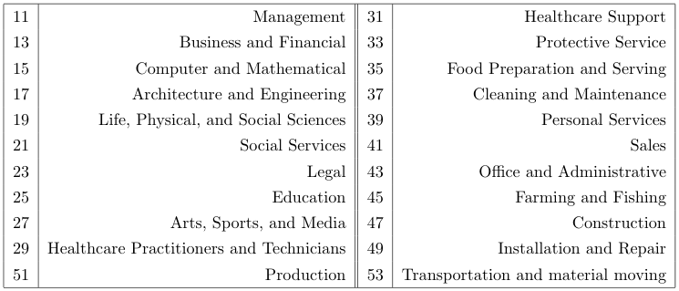

NOTE: figure/graphic rendered as an image from the PDF; its content is not machine-readable text. Caption (if any) follows as the next block.

**text found inside the figure**

11 Management 31 Healthcare Support

13 Business and Financial 33 Protective Service

15 Computer and Mathematical 35 Food Preparation and Serving

17 Architecture and Engineering 37 Cleaning and Maintenance

19 Life, Physical, and Social Sciences 39 Personal Services

21 Social Services 41 Sales

23 Legal 43 Office and Administrative

25 Education 45 Farming and Fishing

27 Arts, Sports, and Media 47 Construction

29 Healthcare Practitioners and Technicians 49 Installation and Repair

51 Production 53 Transportation and material moving

ratio in the data, and keeps the dimensions of heterogeneity tractable (for a similar

strategy, see occupational groups in Davis and Dingel, 2020).

Since the O*NET data is released typically twelve to sixteen months after the infor-

mation is collected (the 2015 survey release pertains to 2014, the 2014 one to 2013

and so on), I match the *t* OES shares with the *t* + 1 O*NET release. I also match

O*NET data from the 2002 release (pertaining to 2001) to the 2000 OES survey,

under the assumption that skill profiles for 2-digits occupations did not change sub-

stantially in that year. I do not use the 2001 release of O*NET because it is not

constructed with criteria consistent with following years — in particular, O*NET

surveys before 2002 were not employee-level but only addressed to “occupational

experts”. This matching procedure turns out to be inconsequential for the final

results.

In my baseline analysis, I attribute to jobs between 1994 and 2000 the skill profile of

their occupation as measured by O*NET in 2000. I exclude Teaching occupations

(SOC2=25) and Agricultural Occupations (SOC2=45) because of the peculiar wage

and wage growth distributions for workers employed in these occupations. These

choices are immaterial with respect to my final results because of the very small

number of teachers and agricultural workers who undergo layoff episodes.

#### **A.2 Complete List of Skills from O*NET**

• Active Learning

• Active Listening

• Complex Problem Solving

• Coordination

• Critical Thinking

• Equip. Maintenance

• Equip. Selection

• Installation

• Instructing

• Judgment/Decision Making

• Learning Strategies

• Financial Management

• Materials Management

• Personnel Management

• Mathematics

• Monitoring

• Negotiation

• Operation Monitoring

• Operation and Control

• Operations Analysis

• Persuasion

• Programming

• Quality Control Analysis

• Reading Comprehension

• Repairing

• Science

• Service Orientation

• Social Perceptiveness

• Speaking

• Systems Analysis

• Systems Evaluation

• Technology Design

• Time Management

• Troubleshooting

• Writing

Figure A.1: The O*NET Skills questionnaire

[figure not shown]

NOTE: figure/graphic rendered as an image from the PDF; its content is not machine-readable text. Caption (if any) follows as the next block.

#### **A.3 Earnings and wages in the NLSY79**

In my baseline analysis, I drop all observations that pertain to teachers (SOC 25)

because their wage is usually set through non-market mechanisms, for example by

collective bargaining. I also drop agricultural occupations (SOC 45) because of

their peculiarly seasonal wage volatility. The omission of agricultural occupations is

inconsequential, given the small shares of employment these jobs represent. Results

are robust to the inclusion of SOC 25 occupations as well.

I impute wages as follows, when missing: (i) where the hourly wage is missing but

the annual wage is provided, I impute the hourly wage by dividing the annual wage

by the number of paid weeks reported and then by the number of weekly hours

worked. (ii) If either weeks or hours are missing but the worker responds negatively

to the question about part-time status, I presume that the worker works 40 hours

per week and 52 weeks a year. (iii) If the worker works part-time and no hourly

wage is reported, the observation is dropped. This affects less than 0.1% of the

sample, and the results are robust to my imputation procedure.

Finally, in all earnings and wage regressions, both the first and last percentile of the

wage distribution are omitted from the analysis for robustness. Including them only

reinforces my results but may give excessive importance to outliers. I also replicated

the results while omitting the top and bottom 5% of the wage distribution and using

log wages. Results are unchanged.

### **B Local skill remoteness**

#### **B.1 Vacancy and employment shares**

While plausible, the choice of employment weights for local skill remoteness is not

obvious and primarily reflects data constraints. Indeed, an attractive alternative

is the share of *vacant* jobs by occupation and metropolitan area. However, a long

and spatially comprehensive time series for occupation-city level vacancies is not

available for the U.S.. Data on job openings is often limited to online sources only,

has a limited level of detail, or is available only since the late 2000s.

Data on local job ads is available for the U.S. in two datasets: the Help Wanted

Online (HWOL) and the Burning Glass (BG) data. In particular, the HWOL re-

ports disaggregated vacancy counts only for the largest 45 metropolitan areas in the

U.S. since 2005. BG data, instead, provides information on detailed occupations in

all 382 metropolitan areas since 2010, but the level of vacancy posting is underesti-

mated for low-skill occupations and the data is only available since 2010 (Hershbein

and Kahn, 2018). On the other hand, employment shares are readily available from

comprehensive data sources at a rather granular level (occupation-by-metro area)

since the 1990s. Therefore, I choose to use employment shares in my main speci-

fication, as such data is available for all metropolitan areas at the chosen level of

occupational detail since the early 1990s. For the available cities, occupations, and

years, I find that the discrepancy between employment and job postings shares is

I recognize that this empirical strategy is far from unrestrictive, I take comfort in

the fact that it is ultimately empirically successful: the employment-weighted local

skill remoteness of a worker’s last job predicts a number of post-layoff outcomes of

interest and reveals interesting heterogeneity in the consequences of layoff.

It is reassuring that local occupational employment shares and local occupational

vacancy shares are strongly correlated in the cross-section and over time. Employ-

ment shares in the OES — the weights of choice in my baseline formulation of local

skill remoteness — are strongly and positively correlated with vacancy shares in

both HWOL and BG. For the cities, occupations, and years available in HWOL,

the cross-sectional correlation between the vacancy- and employment-weighted skill

remoteness measures is between 0.62 (2010) and 0.75 (2016), with an average of 0.74

over the whole period (2005-2016). The correlation using BG job postings data for

2010-2016 is also high, and equal to 0.75.

### **C Additional empirical results**

#### **C.1 Descriptive analysis: skill distances**

I use skill scores from O*NET to construct pairwise skill distances between occu-

pations. In my main specification, I use the Manhattan distance and denote the

skill-distance between occupation *i* and occupation *j* by *dij* as in (1). Table C.1

shows the closest and farthest occupations for selected occupational groups, accord-

ing to the skill distance from O*NET. To compute skill distances I use all the 35

skill dimensions available in the data, without imposing weights nor aggregation.

This approach reflects the empirical evidence that occupations combine several, of-

ten diverse, types of skills at varying intensity. Broad skill groups such as cognitive

and manual skills are not necessarily mutually exclusive: indeed, as Fernandez-

Macias, Hurley, and Storrie (2012) document for European countries, I also find

that many jobs display a balanced combination of cognitive, manual, and interper-

sonal skills.

Consider, for example, the jobs in table C.2. Anesthesiologists and economists are

often thought of as prevalently cognitive occupations, and so they are. Yet skills

related to social interaction (such as listening, speaking, or monitoring others) play

an important role in the performance of these occupations. Machinists and ma-

sons tend to be classified as manual occupations, yet among the five top skills these

workers use we find coordination, listening, and critical thinking. Similarly, occu-

pations that are intensive in social skills (baristas or nurses, for instance) also use

cognitive ones, such as coordination, monitoring, and critical thinking. In general,

though some jobs are more pronouncedly cognitive (anesthesiologists) and other

predominantly manual (masons), almost all occupations combine various skills in a

non-trivial way and at different levels of complexity to produce services and goods

(see table C.3). Therefore, I exploit the full richness of skill dimensions in O*NET

and let the data speak to each skill dimension’s relevance.

Table C.1: Skill-distances across selected occupational groups. Source: O*NET 2017.

| Occupation | Closest | Farthest |
| --- | --- | --- |
| Economist | Statisticians | Construction workers |
| Physicians and Pharmacists | Biologists | Cooks and Waiters |
| Machine Operators | Laborers and Material Movers | Chief executives |
| Masons | Production and Operating workers | Chief executives |
| Baristas and Bartenders | Housekeepers and Janitors | Architects and Engineers |

NOTE: table converted from PDF layout to HTML text; cell boundaries are reconstructed. See PDF if exact alignment matters.

Table C.2: Top 5 skills for different occupations: occupations combine several, often diverse,

types of skills. Source: O*NET 2017.

| Occupation Skill | Occupation Skill |
| --- | --- |
| Anesthesiologist Critical Thinking Active Listening Decision Making Monitoring Problem Solving | Economist Active Listening Critical Thinking Mathematics Speaking Writing |
| Machinist Operation Monitoring Critical Thinking Operation and Control Active Listening Coordination | Cement Mason Monitoring Active Listening Coordination Critical Thinking Decision Making |
| Barista Active Listening Service Orientation Social Perceptiveness Speaking Coordination | Critical Care Nurse Active Listening Service Orientation Critical Thinking Monitoring Reading |

NOTE: table converted from PDF layout to HTML text; cell boundaries are reconstructed. See PDF if exact alignment matters.

Table C.3: Level and importance of listening skills across occupations. Source: O*NET

2017.

|  | Skill | Occupation | Level† | Importance† |
| --- | --- | --- | --- | --- |
| Active | listening | Anesthesiologist | 78 | 61 |
|  |  | Economist | 75 | 59 |
|  |  | Machinist | 50 | 41 |
|  |  | Mason | 53 | 34 |
|  |  | Barista | 63 | 37 |
|  |  | Nurse | 78 | 57 |

NOTE: table converted from PDF layout to HTML text; cell boundaries are reconstructed. See PDF if exact alignment matters.

† min=0, max=100

#### **C.2 Skills distances and occupational flows**

Skill distances are highly predictive of cross-occupational flows. I interpret this

evidence as confirming the validity of measuring workers’ skill remoteness starting

from distances between jobs in the skill space. Specifically, I find that the distance

between the two occupations *dij* is inversely related to the probability of *ij* worker

flows, with an elasticity very close to -1. In other words, the larger the skill distance

between two occupations, the smaller the probability a worker transitions to be

employed from one to the other.

To show the negative relationship between skill distances and cross-occupational

flows, I construct two different measures of occupational change rates using longitudinally-

linked CPS micro-data 1994-2016. The first measure considers all workers that were

employed in occupation *i* at month *t* and employed in occupation *j* ≠*i* at month

*t* + 1. The rate is computed as a percentage of all workers employed in *i* at *t*. I

denote these monthly flow rates by *fij*. As an alternative measure, I compute gen-

eralized flow rates that consider all workers employed in occupation *i* at month *t* and

employed in occupation *j* ≠*i* at any of the months between *t* + 1 and *t* + 3. Again,

the rate is computed as a percentage of all workers employed in *i* at *t*. I denote

these generalized flow rates by <sup>˜</sup>*fij*. Notice that *fij* excludes workers who experience

an occupational change episode through a spell of non-employment, while <sup>˜</sup>*fij* does

not.

To investigate the relationship between skill distances and flows, I run a series of

regressions of log occupational flows (either monthly or generalized) on log skill

distances. The estimated elasticities are in table C.4. In columns 1 and 3, I test the

Table C.4: Skill distances are highly predictive of cross-occupational flows: a 1% increase

in the distance between occupations is associated with a 1% decrease in the worker flow

between them. Standard errors clustered by outgoing occupation *i*. Source: O*NET and

|  | (1) | (2) | (3) | (4) |
| --- | --- | --- | --- | --- |
|  | ln(flow) | ln(flow) | ln( generalized flow) | ln( generalized flow) |
| ln(distance) | 1 068** - . | 1 086** - . | 1 053** - . | 1 160** - . |
|  | (0 0968) . | (0 0637) . | (0 102) . | (0 0761) . |
| i FE | No | Yes | No | Yes |
| j FE | No | Yes | No | Yes |
| R -squared | 0 227 . | 0 802 . | 0 204 . | 0 799 . |

NOTE: table converted from PDF layout to HTML text; cell boundaries are reconstructed. See PDF if exact alignment matters.

Significance levels : † = 10% ∗= 5% ∗∗= 1%

relationship between skill distances and flow rates (monthly and generalized) and

find that it is negative, with an elasticity tightly estimated around -1 in both cases,

and a contribution of skill distances to the variance of flows rates of at least 20%.

In columns 2 and 4, I add fixed effects for the outgoing and receiving occupations to

the baseline specification: I find that the estimated elasticity of cross-occupational

flows to skill distances is again estimated tightly around -1. I conclude that a 1%

increase in the distance between two occupations is associated with a 1% decrease

in the worker flow between them. This result is robust across several empirical

specifications, thus emphasizing how, even when I allow for differential means for

the outgoing and receiving occupations, skill distances between jobs are a major

determinant of cross-occupational worker mobility.

#### **C.3 Unemployment duration**

Table C.5: Distribution of unemployment duration, in weeks, by the local skill-

remoteness of the lost job. Source: CPS-DWS 1994-2017. Recession years are 2001,

and 2007-10.

| Percentile | All years Recessions |  |  |  |
| --- | --- | --- | --- | --- |
|  | Skill -central | Skill -remote | Skill -central | Skill -remote |
| 1% 5% 10% 25% Median Mean 75% 90% 95% 99% | 1 1 2 4 12 23 4 . 30 60 104 119 | 1 1 2 4 12 24 9 . 34 63 104 119 | 1 1 2 5 13 26 4 . 39 64 91 117 | 1 1 2 5 14 27 0 . 39 65 104 119 |

NOTE: table converted from PDF layout to HTML text; cell boundaries are reconstructed. See PDF if exact alignment matters.

In the CPS, one can measure the separation rate of workers whose last job was

either skill-remote or skill-central *at the monthly frequency*. This implies that short

unemployment spells may go undetected if they start after the interview date at

month *m* and end before the interview date at month *m* + 1. One hypothesis could

be that such short unemployment spells are much more likely for workers separating

from skill-central jobs. Then, the rates of job destruction could actually be the same

for skill-central and skill-remote jobs, but the job-finding rate faster for workers

laid-off from skill-central ones. The CPS evidence on separation rates alone cannot

distinguish between this scenario and one in which skill-remote jobs are, in fact,

destroyed at a faster rate in recessions than skill-central ones.

While theoretically possible, in the data there is little evidence of differential in-

cidence of short unemployment spells by skill remoteness at layoff. In the CPS,

every unemployed person is asked the duration of the current unemployment spell

— many of these spells last less than 4 weeks, in fact. The overall distribution of

unemployment duration, however, does not differ in any appreciable way between

laid-off workers whose last job was above or below the median local skill remote-

ness. This statement is especially true for short unemployment spells, as detailed

in table C.5. In both groups, about 25% of laid-off workers have unemployment

duration of at most 4 weeks, and the median is 12 weeks in both cases. At longer

duration we do see some differences, but they are relatively small. In recessions,

long unemployment spells. This is consistent with the evidence in section 4.3, as

who lost a skill-central or a skill-remote job.

#### **C.4 Migration and occupational change**

Of those workers that change city, approximately 1 in 2 also change occupation. For

migrants who also change occupation after moving to a different metro-area, the

total change in remoteness is the sum of two components. First, the change in local

skill remoteness of the old occupation between the old and new city, the “spatial

component”. Second, the change in local skill remoteness between the old and the

new occupation in the new city, the “occupational component”. Then, the overall

change in local skill remoteness can be written as follows, where “prime” denotes

post-migration variables:

R*oc* −R*o*<sup>′</sup>*c*<sup>′</sup> =

**equation / math rendering (image)**

NOTE: contains mathematical notation; text above is the PDF text layer and symbols may be mis-extracted. Image shows the original.

= (R*oc* −R*oc*<sup>′</sup>) −(R*o*<sup>′</sup>*c*<sup>′</sup> −R*oc*<sup>′</sup>)

**equation / math rendering (image)**

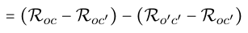

NOTE: contains mathematical notation; text above is the PDF text layer and symbols may be mis-extracted. Image shows the original.

On average, (R*oc* −R*oc*<sup>′</sup>) — the spatial change in the skill remoteness of the old

occupation — accounts for 40% of the overall average decline (table C.6). This,

however, masks a more varied distribution, with multiple peaks at 5, 20, and 60

percent (figure C.1).

Table C.6: Summary stats for the spatial change in the old occupation between the

old and new city R*oc* −R*oc*<sup>′</sup>, expressed as a percentage of actual post-migration skill

remoteness change R*oc* −R*o*<sup>′</sup>*c*<sup>′</sup>.

Percentiles Value

1% 2.319

5% 2.330

10% 3.579

25% 17.166

Median 39.130

Mean 39.695

75% 62.595

90% 83.444

95% 91.647

99% 93.651

Figure C.1: For migrants who change occupation after moving to a different metro-

area, the distribution of the spatial component R*oc* −R*oc*<sup>′</sup> has multiple peaks.

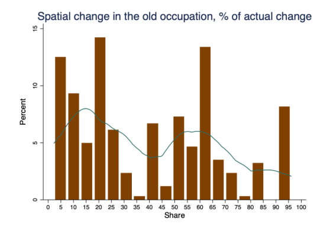

NOTE: figure/graphic rendered as an image from the PDF; its content is not machine-readable text. Caption (if any) follows as the next block.